# Anomaly Detection in Network Traffic with K-means clustering

We can categorize machine learning algorithms into two main groups: **supervised learning** and **unsupervised learning**. With supervised learning algorithms, in order to predict unknown values for new data, we have to know the target value for many previously-seen examples. In contrast, unsupervised learning algorithms explore the data which has no target attribute to find some intrinsic structures in them.

Clustering is a technique for finding similar groups in data, called **clusters**. Clustering is often called an unsupervised learning task as no class values denoting an a priori grouping of the data instances are given.

In this notebook, we will use K-means, a very well known clustering algorithm to detect anomaly network connections based on statistics about each of them. For a thorough overview of K-means clustering, from a research perspective, have a look at this wonderful [tutorial](http://theory.stanford.edu/~sergei/slides/kdd10-thclust.pdf).

## Goals

We expect students to:

- Learn (or revise) and understand the K-means algorithm
- Implement a simple K-means algorithm
- Use K-means to detect anomalies network connection data

## Steps

1. In section 1, we will have an overview about K-means then implement a simple version of it.
2. In section 2, we build models with and without categorical features.
3. Finally, in the last section, using our models, we will detect unsual connections.

# 1. K-means

## 1.1. Introduction

Clustering is a typical and well-known type of unsupervised learning. Clustering algorithms try to find natural groupings in data. Similar data points (according to some notion of similarity) are considered in the same group. We call these groups **clusters**.

K-Means clustering is a simple and widely-used clustering algorithm. Given value of $k$, it tries to build $k$ clusters from samples in the dataset. Therefore, $k$ is an hyperparameter of the model. The right value of $k$ is not easy to determine, as it highly depends on the data set and the way that data is featurized.

To measue the similarity between any two data points, K-means requires the definition of a distance funtion between data points. What is a distance? It is a value that indicates how close two data points are in their space. In particular, when data points lie in a $d$-dimensional space, the Euclidean distance is a good choice of a distance function, and is supported by MLLIB.

In K-means, a cluster is a group of points, with a representative entity called a centroid. A centroid is also a point in the data space: the center of all the points that make up the cluster. It's defined to be the arithmetic mean of the points. In general, when working with K-means, each data sample is represented in a $d$-dimensional numeric vector, for which it is easier to define an appropriate distance function. As a consequence, in some applications, the original data must be transformed into a different representation, to fit the requirements of K-means.

## 1.2. How does it work ?

Given $k$, the K-means algorithm works as follows:

1. Randomly choose $k$ data points (seeds) to be the initial centroids
2. Assign each data point to the **closest centroid**
3. Re-compute (update) the centroids using the current cluster memberships
4. If a convergence criterion is not met, go to step 2

We can also terminate the algorithm when it reaches an iteration budget, which yields an approximate result. From the pseudo-code of the algorithm, we can see that K-means clustering results can be sensitive to the order in which data samples in the data set are explored. A sensible practice would be to run the analysis several times, randomizing objects order; then, average the cluster centres of those runs and input the centres as initial ones for one final run of the analysis.

## 1.3. Illustrative example

One of the best ways to study an algorithm is trying implement it. In this section, we will go step by step to implement a simple K-means algorithm.

[figure not shown]

### Question 1

#### Question 1.1

Complete the below function to calculate an euclidean distance between any two points in $d$-dimensional data space

```python
import numpy as np
import warnings
warnings.filterwarnings("ignore")

# calculate distance between two d-dimensional points
def euclidean_distance(p1, p2):
    return np.sqrt(np.sum(np.power(np.array(p1)-np.array(p2),2)))

# test our function
assert (round(euclidean_distance([1,2,3] , [10,18,12]), 2) == 20.45), "Function's wrong"
```

#### Question 1.2

Given a data point and the current set of centroids, complete the function below to find the index of the closest centroid for that data point.

```python
def find_closest_centroid(datapoint, centroids):
    # find the index of the closest centroid of the given data point.
    distToCentroids = min(enumerate(centroids), key=lambda x: euclidean_distance(datapoint, x[1]))[0]
    return distToCentroids
assert(find_closest_centroid( [1,1,1], [ [2,1,2], [1,2,1], [3,1,2] ] ) == 1), "Function's wrong"
```

#### Question 1.3

Write a function to randomize `k` initial centroids.

```python
np.random.seed(22324)

# randomize initial centroids
def randomize_centroids(data, k):
    np.random.shuffle(data)
    centroids = data[:k]
    return centroids

assert(len(
    randomize_centroids(
        np.array([
            np.array([2,1,2]),
            np.array([1,2,1]),
            np.array([3,1,2])
             ]),
        2)) == 2), "Wrong function"
```

#### Question 1.4

Write function `check_converge` to check the stop creteria of the algorithm.

```python
MAX_ITERATIONS = 10

# return True if clusters have converged , otherwise, return False
def check_converge(centroids, old_centroids, num_iterations, threshold=0):
    # if it reaches an iteration budget
    if (num_iterations > MAX_ITERATIONS):
        return True
    # check if the centroids don't move (or very slightly)
    updatedDis = np.array([euclidean_distance(co,cn) for co,cn in zip(old_centroids,centroids)])
    if np.all(updatedDis<=threshold):
        return True
```

#### Question 1.5

Write function `update_centroid` to update the new positions for the current centroids based on the position of their members.

```python
def update_centroids(centroids, clusters):
    assert(len(centroids) == len(clusters),"Number of clusters != Number of centroids")
    centroids = np.array([np.sum(members,axis=0)/len(members) for members in clusters])
    return centroids
```

#### Question 1.6

Complete the K-means algorithm scheleton below, with the functions you wrote above.

```python
# data : set of data points
# k : number of clusters
# centroids: initial list of centroids
def kmeans(data, k=2, centroids=None):

    # randomize the centroids if they are not given
    if not centroids:
        centroids = randomize_centroids(data,k)

    old_centroids = centroids[:]

    iterations = 0
    while True:
        iterations += 1

        # init empty clusters
        clusters = [[] for i in range(k)]

        # assign each data point to the closest centroid
        for dPoint in data:
            # find the closest center of each data point

            centroid_idx = find_closest_centroid(dPoint,centroids)
            # assign datapoint to the closest cluster
            clusters[centroid_idx].append(dPoint)

        # keep the current position of centroids before changing them
        old_centroids = centroids

        # update centroids
        centroids = update_centroids(centroids,clusters)

        # if the stop criteria are met, stop the algorithm
        if check_converge(centroids, old_centroids, iterations, 1e-5):
            break

    return centroids
```

Next, we will test our algorithm on [Fisher's Iris dataset](http://en.wikipedia.org/wiki/Iris_flower_data_set), and plot the resulting clusters in 3D.

#### Question 1.7

The code below can be used to test your algorithm with three different datasets: `Iris`, `Moon` and `Blob`. Run your algorithm to cluster datapoints in these datasets, plot the results and discuss about them. Do you think that our algorithm works well? Why?

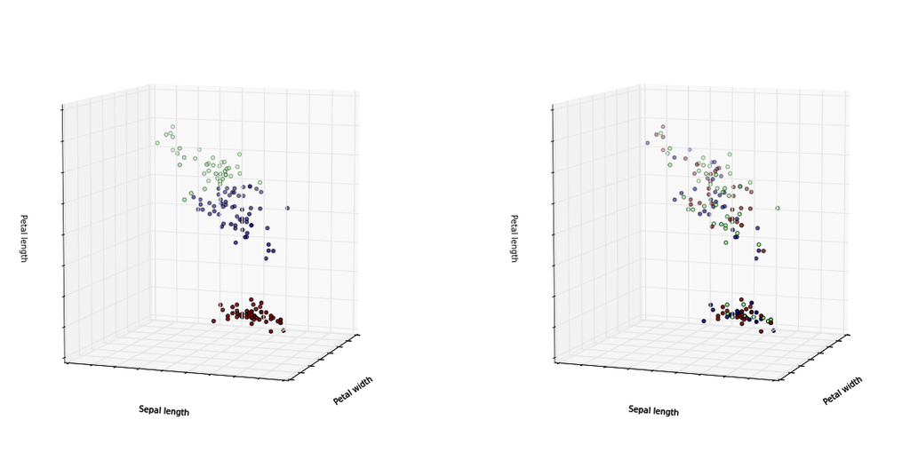

```python
# the sourcecode in this cell is inspired from
# https://gist.github.com/bbarrilleaux/9841297

%matplotlib inline

from sklearn import datasets, cluster
import numpy as np
import matplotlib.pyplot as plt
from mpl_toolkits.mplot3d import Axes3D


# load data
iris = datasets.load_iris()
X_iris = iris.data
y_iris = iris.target
# do the clustering
centers = kmeans(X_iris, k=3)
labels = [find_closest_centroid(p, centers) for p in X_iris]

#plot the clusters in color
fig = plt.figure(1, figsize=(20, 10))
plt.clf()
ax = plt.subplot(1,2,1,projection='3d')
plt.cla()
ax.scatter(X_iris[:, 3], X_iris[:, 0], X_iris[:, 2], c=labels)

ax.w_xaxis.set_ticklabels([])
ax.w_yaxis.set_ticklabels([])
ax.w_zaxis.set_ticklabels([])
ax.set_xlabel('Petal width')
ax.set_ylabel('Sepal length')
ax.set_zlabel('Petal length')
ax.view_init(elev=8, azim=200)

ax = plt.subplot(1,2,2,projection='3d')
plt.cla()
ax.scatter(X_iris[:, 3], X_iris[:, 0], X_iris[:, 2], c=y_iris)

ax.w_xaxis.set_ticklabels([])
ax.w_yaxis.set_ticklabels([])
ax.w_zaxis.set_ticklabels([])
ax.set_xlabel('Petal width')
ax.set_ylabel('Sepal length')
ax.set_zlabel('Petal length')
ax.view_init(elev=8, azim=200)

# Here we use sci-kit learn implementation of K-means
# centers =cluster.KMeans(n_clusters=3)
# centers.fit(X_iris)
# labels = centers2.labels_
```

it seems the label from the clustering does not match with data. We think that you want to use this data set to visualize how k-means work in this distribution of the features

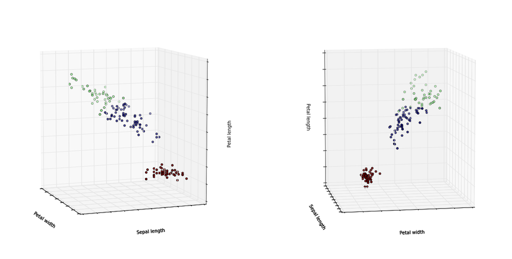

```python
#plot the clusters in color
fig = plt.figure(1, figsize=(20, 10))
plt.clf()
ax = plt.subplot(1,2,1,projection='3d')
plt.cla()
ax.scatter(X_iris[:, 3], X_iris[:, 0], X_iris[:, 2], c=labels)

ax.w_xaxis.set_ticklabels([])
ax.w_yaxis.set_ticklabels([])
ax.w_zaxis.set_ticklabels([])
ax.set_xlabel('Petal width')
ax.set_ylabel('Sepal length')
ax.set_zlabel('Petal length')
ax.view_init(elev=8, azim=160)

ax = plt.subplot(1,2,2,projection='3d')
plt.cla()
ax.scatter(X_iris[:, 3], X_iris[:, 0], X_iris[:, 2], c=labels)

ax.w_xaxis.set_ticklabels([])
ax.w_yaxis.set_ticklabels([])
ax.w_zaxis.set_ticklabels([])
ax.set_xlabel('Petal width')
ax.set_ylabel('Sepal length')
ax.set_zlabel('Petal length')
ax.view_init(elev=8, azim=260)
```

```python
print("Dimension of the data: ",np.shape(X_iris))
```

```
Dimension of the data:  (150, 4)
```

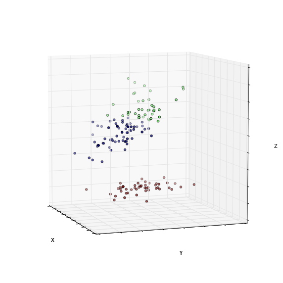

```python
centers = kmeans(X_iris, k=3)
labels = [find_closest_centroid(p, centers) for p in X_iris]
# load data
pca = PCA(copy=True, n_components=3, whiten=False)
score = pca.fit_transform(X_iris)

fig = plt.figure(figsize=(10, 10))
ax = plt.subplot(1,1,1,projection='3d')
plt.cla()
ax.scatter(score[:, 2], score[:, 1], score[:, 0], c=labels)
ax.view_init(elev=8, azim=160)
ax.w_xaxis.set_ticklabels([])
ax.w_yaxis.set_ticklabels([])
ax.w_zaxis.set_ticklabels([])
ax.set_xlabel('X')
ax.set_ylabel('Y')
ax.set_zlabel('Z')

plt.show()
```

In this case, we use PCA to reduce dimensions into 3 with choosing 3 largest possible variance demensions (highest eigenvalue). Then we see that data is more clearly seperated to 3 clusters.  
In our opinion, the algorithm work well we can observe that points seem near points in its cluster but far enough from points from other clusters.

That's enough about K-means for now. In the next section, we will apply MMLIB's K-means on Spark to deal with a large data in the real usecase.

# 2. Usecase: Network Intrusion

Some attacks attempt to flood a computer with network traffic. In some other cases, attacks attempt to exploit flaws in networking software in order to gain unauthorized access to a computer. Detecting an exploit in an incredibly large haystack of network requests is not easy.

Some exploit behaviors follow known patterns such as scanning every port in a short of time, sending a burst of request to a port... However, the biggest threat may be the one that has never been detected and classified yet. Part of detecting potential network intrusions is detecting anomalies. These are connections that aren't known to be attacks, but, do not resemble connections that have been observed in the past.

In this notebook, K-means is used to detect anomalous network connections based on statistics about each of them.

## 2.1. Data

The data comes from [KDD Cup 1999](http://kdd.ics.uci.edu/databases/kddcup99/kddcup99.html). The dataset is about 708MB and contains about 4.9M connections. For each connection, the data set contains information like the number of bytes sent, login attempts, TCP errors, and so on. Each connection is one line of CSV-formatted data, containing 38 features: back, buffer_overflow, ftp_write, guess_passwd, imap, ipsweep, land, loadmodule, multihop, neptune, nmap, normal, perl, phf, pod, portsweep, rootkit, satan, smurf, spy, teardrop, warezclient, warezmaster. For more details about each features, please follow this [link](http://kdd.ics.uci.edu/databases/kddcup99/kddcup99.html).

Many features take on the value 0 or 1, indicating the presence or absence of a behavior such as `su_attempted` in the 15th column. Some features are counts, like `num_file_creations` in the 17th columns. Some others are the number of sent and received bytes.

## 2.2. Clustering without using categorical features

First, we need to import some packages that are used in this notebook.

```python
import os
import sys
import re
import time
from pyspark import SparkContext
from pyspark import SparkContext
from pyspark.sql import SQLContext
from pyspark.sql.types import *
from pyspark.sql import Row
import pyspark.sql.functions as func
%matplotlib inline

from collections import Counter
import time
import matplotlib.pyplot as plt
import matplotlib.cm as cm
import pandas as pd
import numpy as np
import pyspark.sql.functions as func
import matplotlib.patches as mpatches
from pyspark.mllib.clustering import KMeans, KMeansModel
from pyspark.mllib.feature import PCA as PCAmllib
from pyspark.mllib.linalg import Vectors
from sklearn.decomposition import PCA
import warnings
from operator import add
warnings.filterwarnings("ignore")

input_path = "/datasets/k-means/kddcup.data"
raw_data = sc.textFile(input_path, 12)
```

```python
raw_data.take(5)
```

```
['0,tcp,http,SF,215,45076,0,0,0,0,0,1,0,0,0,0,0,0,0,0,0,0,1,1,0.00,0.00,0.00,0.00,1.00,0.00,0.00,0,0,0.00,0.00,0.00,0.00,0.00,0.00,0.00,0.00,normal.',
 '0,tcp,http,SF,162,4528,0,0,0,0,0,1,0,0,0,0,0,0,0,0,0,0,2,2,0.00,0.00,0.00,0.00,1.00,0.00,0.00,1,1,1.00,0.00,1.00,0.00,0.00,0.00,0.00,0.00,normal.',
 '0,tcp,http,SF,236,1228,0,0,0,0,0,1,0,0,0,0,0,0,0,0,0,0,1,1,0.00,0.00,0.00,0.00,1.00,0.00,0.00,2,2,1.00,0.00,0.50,0.00,0.00,0.00,0.00,0.00,normal.',
 '0,tcp,http,SF,233,2032,0,0,0,0,0,1,0,0,0,0,0,0,0,0,0,0,2,2,0.00,0.00,0.00,0.00,1.00,0.00,0.00,3,3,1.00,0.00,0.33,0.00,0.00,0.00,0.00,0.00,normal.',
 '0,tcp,http,SF,239,486,0,0,0,0,0,1,0,0,0,0,0,0,0,0,0,0,3,3,0.00,0.00,0.00,0.00,1.00,0.00,0.00,4,4,1.00,0.00,0.25,0.00,0.00,0.00,0.00,0.00,normal.']
```

### 2.2.1. Loading data

There are two types of features: numerical features and categorical features. Currently, to get familiar with the data and the problem, we only use numerical features. In our data, we also have pre-defined groups for each connection, which we can use later as our "ground truth" for verifying our results.

**Note 1**: we don't use the labels in the training phase !!!

**Note 2**: in general, since clustering is un-supervised, you don't have access to ground truth. For this reason, several metrics to judge the quality of clustering have been devised. For a short overview of such metrics, follow this [link](https://en.wikipedia.org/wiki/Cluster_analysis#Internal_evaluation). Note that computing such metrics, that is trying to assess the quality of your clustering results, is as computationally intensive as computing the clustering itself!

[figure not shown]

#### Question 2

Write function `parseLine` to construct a tuple of `(label, vector)` for each connection, extract the data that contains only the data points (without label), then print the number of connections.

Where,

- `label` is the pre-defined label of each connection
- `vector` is a numpy array that contains values of all features, but the label and the categorial features at index `1,2,3` of each connection. Each `vector` is a data point.

```python
def parseLine(line):
    cols = line.split(',')
    # label is the last column
    label = cols[-1]

    # vector is every column, except the label
    vector = cols[:-1]

    # delete values of columns that have index 1->3 (categorical features)
    vector[1:4] = []

    # convert each value from string to float
    vector = np.array(vector).astype(float)

    return (label, vector)

labelsAndData = raw_data.map(lambda line: parseLine(line))

# we only need the data, not the label
data = labelsAndData.map(lambda x: x[1]).cache()
label = labelsAndData.map(lambda x: x[0]).cache()

# number of connections
n = data.count()
print("NUMBER OF CONNECTIONS: ", n)
print("NUMBER OF DIMENSION: ", len(data.take(1)[0]))
```

```
NUMBER OF CONNECTIONS:  4898431
NUMBER OF DIMENSION:  38
```

```python
labelsAndData.take(2)
```

```
[('normal.', array([  0.00000000e+00,   2.15000000e+02,   4.50760000e+04,
           0.00000000e+00,   0.00000000e+00,   0.00000000e+00,
           0.00000000e+00,   0.00000000e+00,   1.00000000e+00,
           0.00000000e+00,   0.00000000e+00,   0.00000000e+00,
           0.00000000e+00,   0.00000000e+00,   0.00000000e+00,
           0.00000000e+00,   0.00000000e+00,   0.00000000e+00,
           0.00000000e+00,   1.00000000e+00,   1.00000000e+00,
           0.00000000e+00,   0.00000000e+00,   0.00000000e+00,
           0.00000000e+00,   1.00000000e+00,   0.00000000e+00,
           0.00000000e+00,   0.00000000e+00,   0.00000000e+00,
           0.00000000e+00,   0.00000000e+00,   0.00000000e+00,
           0.00000000e+00,   0.00000000e+00,   0.00000000e+00,
           0.00000000e+00,   0.00000000e+00])),
 ('normal.', array([  0.00000000e+00,   1.62000000e+02,   4.52800000e+03,
           0.00000000e+00,   0.00000000e+00,   0.00000000e+00,
           0.00000000e+00,   0.00000000e+00,   1.00000000e+00,
           0.00000000e+00,   0.00000000e+00,   0.00000000e+00,
           0.00000000e+00,   0.00000000e+00,   0.00000000e+00,
           0.00000000e+00,   0.00000000e+00,   0.00000000e+00,
           0.00000000e+00,   2.00000000e+00,   2.00000000e+00,
           0.00000000e+00,   0.00000000e+00,   0.00000000e+00,
           0.00000000e+00,   1.00000000e+00,   0.00000000e+00,
           0.00000000e+00,   1.00000000e+00,   1.00000000e+00,
           1.00000000e+00,   0.00000000e+00,   1.00000000e+00,
           0.00000000e+00,   0.00000000e+00,   0.00000000e+00,
           0.00000000e+00,   0.00000000e+00]))]
```

```python
labelList = []
for key, value in sorted(label.countByValue().items(), key = lambda x: -x[1]):
    labelList.append((key, value, value/n*100))
dfLabel = pd.DataFrame(labelList,columns=['label','value','percentage'])
pd.options.display.float_format = '{:,.5f}'.format
dfLabel
```

|  | label | value | percentage |
| --- | --- | --- | --- |
| 0 | smurf. | 2807886 | 57.32215 |
| 1 | neptune. | 1072017 | 21.88491 |
| 2 | normal. | 972781 | 19.85903 |
| 3 | satan. | 15892 | 0.32443 |
| 4 | ipsweep. | 12481 | 0.25480 |
| 5 | portsweep. | 10413 | 0.21258 |
| 6 | nmap. | 2316 | 0.04728 |
| 7 | back. | 2203 | 0.04497 |
| 8 | warezclient. | 1020 | 0.02082 |
| 9 | teardrop. | 979 | 0.01999 |
| 10 | pod. | 264 | 0.00539 |
| 11 | guess_passwd. | 53 | 0.00108 |
| 12 | buffer_overflow. | 30 | 0.00061 |
| 13 | land. | 21 | 0.00043 |
| 14 | warezmaster. | 20 | 0.00041 |
| 15 | imap. | 12 | 0.00024 |
| 16 | rootkit. | 10 | 0.00020 |
| 17 | loadmodule. | 9 | 0.00018 |
| 18 | ftp_write. | 8 | 0.00016 |
| 19 | multihop. | 7 | 0.00014 |
| 20 | phf. | 4 | 0.00008 |
| 21 | perl. | 3 | 0.00006 |
| 22 | spy. | 2 | 0.00004 |

```
NUMBER OF LABEL:  23
```

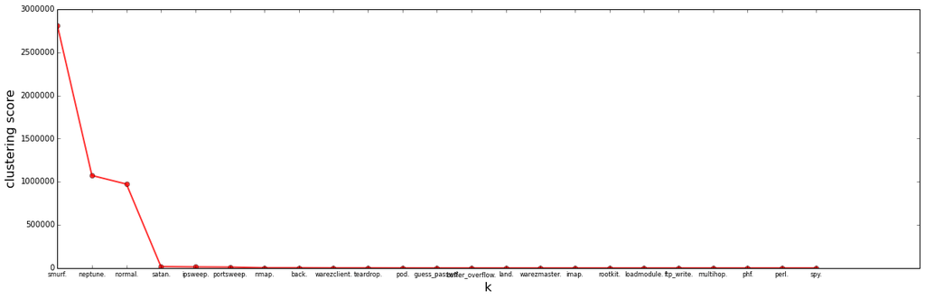

```python
print("NUMBER OF LABEL: ", len(dfLabel.label))
fig = plt.figure(figsize=(20,6))
ax = fig.add_subplot(111)
ax.plot(np.arange(len(dfLabel.label)), dfLabel.value,lw =2, alpha = 0.8,c=cm.autumn(0),linestyle='-',marker='o')
ax.set_xlabel('k',fontsize = 16)
ax.set_xticks(np.arange(len(dfLabel.label)))
ax.set_xticklabels(dfLabel.label,fontsize=8)
ax.set_ylabel('clustering score',fontsize = 16)
plt.show()
```

Brief about our data:

- Data has 4898431 records in 23 classes with 38 dimensions
- Some classes have enomous datapoint: smurf (57.3%), neptune (21.9%), normal (19.9%)
- Hard to sample this dataset because some classes have only few data points. This is unbalanced dataset

[figure not shown]

#### Question 3

Using K-means algorithm of MLLIB, cluster the connections into two groups then plot the result. Why two groups? In this case, we are just warming up, we're testing things around, so "two groups" has no particular meaning.

You can use the following parameters:

- `maxIterations=10`
- `runs=10`
- `initializationMode="random"`

Discuss the result from your figure.

```python
clusters = KMeans.train(data, 2, maxIterations=10, initializationMode="random")
```

```python
a = clusters.predict(data).collect()
Counter(a)
```

```
Counter({0: 2925804, 1: 1972627})
```

We cannot plot result with 38 dimensions so we need to find a way to reduce dimension into 3. There are 2 ways:

- 1 . Using PCA and only keep 3 most important dimensions. One of the problem is that we cannot explain the result in new dimension because new dimensions does not keep the meaning of original data
- 2. We can select 3 dimensions in 38 with defined criteria and plot it. In this case, we will use the 3 features that vary the most (highest variances), because it is intuitive that your data will be spread on that dimension. In addition, lots of features have only 0/1 value so they are not representative enough to visualize by using these features

## PCA - using sklearn

```python
def plotClustersLocalPCA(data, kMeanModel, sampleRate,elev=20,azim=120,labellegend = False):
    colors = iter(cm.rainbow(np.linspace(0, 1, kMeanModel.k)))

    # sampleRate in [0,1] - extract small sample for ploting
    sampledData = data.sample(False, sampleRate)
    sampledDataLocal = np.array(sampledData.collect())

    # get prediction label
    Y_labels = np.array(kMeanModel.predict(sampledData).collect())

    # Using PCA to reduce dimension into 3
    pca = PCA(n_components=3)
    dataNewDim = pca.fit_transform(sampledDataLocal)
    PCA(copy=True, n_components=3, whiten=False)

    #plot the clusters in color
    fig = plt.figure(figsize=(8, 8))
    ax = fig.add_subplot(111, projection='3d')

    for i in set(Y_labels):

        idx = np.where(Y_labels == i)
        curData = dataNewDim[idx]

        ax.scatter(curData[:,0],curData[:,1], curData[:,2],
                   color=next(colors),cmap=plt.cm.bwr,marker=(3, 0),lw = 0,s=100,label='custer %d'%(i))

        ax.view_init(elev=elev,azim=azim)

    ax.set_xlabel('X')
    ax.set_ylabel('Y')
    ax.set_zlabel('Z')
    if labellegend:
        ax.legend(loc='center left', bbox_to_anchor=(1, 0.5))

    plt.show()
```

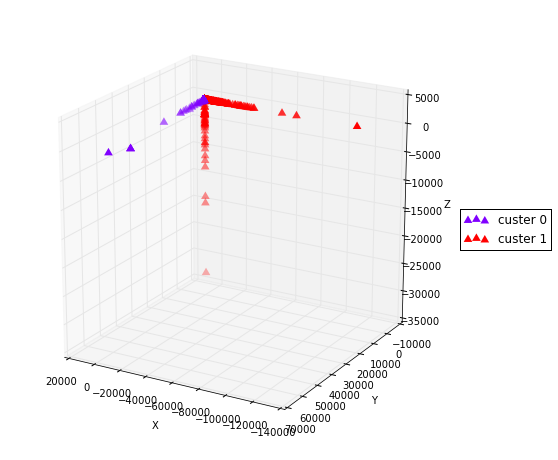

```python
plotClustersLocalPCA(data, clusters, 0.001)
```

## PCA - using MLLIB

```python
def plotClustersDistributedPCA(data, kMeanModel, sampleRate,elev=20,azim=120,labellegend = False):
    colors = iter(cm.rainbow(np.linspace(0, 1, kMeanModel.k)))

    # Find PCA dimension from whole data to reduce dimension into 3
    rdd = data.map(lambda x : Vectors.dense(x))
    model = PCAmllib(3).fit(rdd)

    # sampleRate in [0,1] - extract small sample for ploting
    sampledData = data.sample(False, sampleRate)

    # transform sampledData
    transformed = model.transform(sampledData.map(lambda x : Vectors.dense(x)))
    dataNewDim = np.array(transformed.collect())

    # get prediction label
    Y_labels = np.array(kMeanModel.predict(sampledData).collect())

    #plot the clusters in color
    fig = plt.figure(figsize=(8, 8))
    ax = fig.add_subplot(111, projection='3d')

    for i in set(Y_labels):

        idx = np.where(Y_labels == i)
        curData = dataNewDim[idx]

        ax.scatter(curData[:,0],curData[:,1], curData[:,2],
                   color=next(colors),cmap=plt.cm.bwr,marker=(3, 0),lw = 0,s=100,label='custer %d'%(i))

        ax.view_init(elev=elev,azim=azim)

    ax.set_xlabel('X')
    ax.set_ylabel('Y')
    ax.set_zlabel('Z')

    if labellegend:
        ax.legend(loc='center left', bbox_to_anchor=(1, 0.5))

    plt.show()
```

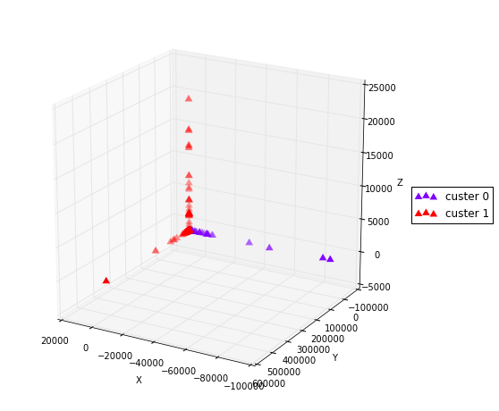

```python
plotClustersDistributedPCA(data, clusters, 0.001)
```

This version I found later, instead of runing PCA on subset of sample, we run PCA on whole data set to find the coordinate and map our sample data into this coordinate. As can be seen that, the shape of the result does not change too much. "RED" class is along 2 dimension and "BLUE" class is along remain dimension.

## Choosing 3 dimensions based on variance

```python
def getVariance(data):
    n = data.count()
    means = data.reduce(add) / n
    variances = data.map(lambda x: np.power((x - means),2)).reduce(add) / n
    return variances
```

```python
variancesData = getVariance(data)
```

```
array([  5.23205909e+05,   8.86292287e+11,   4.16040826e+11,
         5.71608336e-06,   1.83649380e-03,   5.20574220e-05,
         2.19940474e-01,   5.32813401e-05,   1.22928440e-01,
         1.48724429e+01,   6.81804492e-05,   6.53256901e-05,
         1.55084339e+01,   1.54220970e-02,   7.63454566e-05,
         1.26099403e-03,   0.00000000e+00,   4.08293836e-07,
         8.34467881e-04,   4.49400827e+04,   6.05124011e+04,
         1.45828938e-01,   1.46118156e-01,   5.39414093e-02,
         5.41308521e-02,   1.51551218e-01,   6.84170094e-03,
         1.97569872e-02,   4.09867958e+03,   1.12175120e+04,
         1.69073904e-01,   1.17816269e-02,   2.31349138e-01,
         1.70236904e-03,   1.45800386e-01,   1.46059565e-01,
         5.33345749e-02,   5.33506914e-02])
```

```python
pd.DataFrame(variancesData,index=np.arange(len(variancesData))+1,columns=['variance']).sort(['variance'],ascending=0)
```

|  | variance |
| --- | --- |
| 2 | 8.862923e+11 |
| 3 | 4.160408e+11 |
| 1 | 5.232059e+05 |
| 21 | 6.051240e+04 |
| 20 | 4.494008e+04 |
| 30 | 1.121751e+04 |
| 29 | 4.098680e+03 |
| 13 | 1.550843e+01 |
| 10 | 1.487244e+01 |
| 33 | 2.313491e-01 |
| 7 | 2.199405e-01 |
| 31 | 1.690739e-01 |
| 26 | 1.515512e-01 |
| 23 | 1.461182e-01 |
| 36 | 1.460596e-01 |
| 22 | 1.458289e-01 |
| 35 | 1.458004e-01 |
| 9 | 1.229284e-01 |
| 25 | 5.413085e-02 |
| 24 | 5.394141e-02 |
| 38 | 5.335069e-02 |
| 37 | 5.333457e-02 |
| 28 | 1.975699e-02 |
| 14 | 1.542210e-02 |
| 32 | 1.178163e-02 |
| 27 | 6.841701e-03 |
| 5 | 1.836494e-03 |
| 34 | 1.702369e-03 |
| 16 | 1.260994e-03 |
| 19 | 8.344679e-04 |
| 15 | 7.634546e-05 |
| 11 | 6.818045e-05 |
| 12 | 6.532569e-05 |
| 8 | 5.328134e-05 |
| 6 | 5.205742e-05 |
| 4 | 5.716083e-06 |
| 18 | 4.082938e-07 |
| 17 | 0.000000e+00 |

The second feature have highest variances. We will chose the three first features because of highest variances:

- duration: continuous.
- src_bytes: continuous.
- dst_bytes: continuous.

```python
def plotClustersByDataDimension(data, kMeanModel,index_3dim, label_3dim, sampleRate,elev=20,azim=120):
    colors = iter(cm.rainbow(np.linspace(0, 1, kMeanModel.k)))

    # sampleRate in [0,1] - extract small sample for ploting
    sampledData = data.sample(False, sampleRate)
    sampledDataLocal = np.array(sampledData.collect())

    # get prediction label
    Y_labels = np.array(kMeanModel.predict(sampledData).collect())

    #plot the clusters in color
    fig = plt.figure(figsize=(8, 8))
    ax = fig.add_subplot(111, projection='3d')

    for i in set(Y_labels):
        idx = np.where(Y_labels == i)
        curData = sampledDataLocal[idx]

        ax.scatter(curData[:,index_3dim[0]],curData[:,index_3dim[1]], curData[:,index_3dim[2]],
                   color=next(colors),cmap=plt.cm.bwr,marker=(3, 0),lw = 0,s=100,label='custer %d'%(i))
        ax.view_init(elev=elev,azim=azim)

    ax.set_xlabel(label_3dim[0])
    ax.set_ylabel(label_3dim[1])
    ax.set_zlabel(label_3dim[2])
    ax.legend(loc='center left', bbox_to_anchor=(1, 0.5))

    plt.show()
```

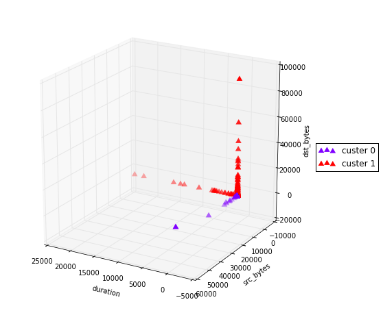

```python
plotClustersByDataDimension(data, clusters,[0,1,2],['duration','src_bytes','dst_bytes'], 0.0004)
```

The result is quite similar to PCA but now we can detail more because we have the meanings of each dimension. The points in class "RED" is vary considerably along 2 dimensions, dts_bytes and duration. While the points in class "Purple" are vary considerably along src_bytes axis. One of the reason that make the result is quite similar is the variance of first 3 dimension is much higher than orther dimension.

```python
for z in range(10):
    print ('----------- Trial %d-th'%(z))
    clusters = KMeans.train(data, 2, maxIterations=10, initializationMode="random")
    sampledData = clusters.predict(data).collect()
    clusterDetail = [(i,sampledData.count(i)) for i in [0,1]]

    for x in clusterDetail:
        print("Number of points in cluster %d = %d"%(x[0],x[1]))
```

```
----------- Trial 0-th
Number of points in cluster 0 = 2925804
Number of points in cluster 1 = 1972627
----------- Trial 1-th
Number of points in cluster 0 = 5
Number of points in cluster 1 = 4898426
----------- Trial 2-th
Number of points in cluster 0 = 5
Number of points in cluster 1 = 4898426
----------- Trial 3-th
Number of points in cluster 0 = 4898426
Number of points in cluster 1 = 5
----------- Trial 4-th
Number of points in cluster 0 = 1972627
Number of points in cluster 1 = 2925804
----------- Trial 5-th
Number of points in cluster 0 = 5
Number of points in cluster 1 = 4898426
----------- Trial 6-th
Number of points in cluster 0 = 4898426
Number of points in cluster 1 = 5
----------- Trial 7-th
Number of points in cluster 0 = 4898431
Number of points in cluster 1 = 0
----------- Trial 8-th
Number of points in cluster 0 = 5
Number of points in cluster 1 = 4898426
----------- Trial 9-th
Number of points in cluster 0 = 4898426
Number of points in cluster 1 = 5
```

Because I found that, I sometimes obtaine different result so I tried to run K-clustering many times and observe number of points on each cluster.  
From the experiment above, we found that initialization point is quite important and it will affect to our final result. In case, it 2 initial points is too close or one of them is far away from data cloud so the final result will contain 1 cluster remain (Trial 7). In addition, the clustering task usually fall into the result one of the cluster have only 5 points.

### 2.2.3. Evaluating model

[figure not shown]

#### Question 4

One of the simplest method to evaluate our result is calculate the Within Set Sum of Squared Errors (WSSSE), or simply, 'Sum of Squared Errors'. An error of a data point is defined as it's distance to the closest cluster center.

```python
t1 = time.time()
# Evaluate clustering by computing Within Set Sum of Squared Errors
def error(clusters, point):
    closest_center = clusters.centers[clusters.predict(point)]
    return euclidean_distance(closest_center,point)**2

WSSSE = data.map(lambda point: error(clusters, point)).reduce(add)
print("Within Set Sum of Squared Error = " + str(WSSSE))
print("RUNNING TIME: ", time.time() - t1)
```

```
Within Set Sum of Squared Error = 6.37937321457e+18
RUNNING TIME:  13.301966428756714
```

```python
t1 = time.time()
print("Within Set Sum of Squared Error = " + str(clusters.computeCost(data)))
print("RUNNING TIME: ", time.time() - t1)
```

```
Within Set Sum of Squared Error = 6.379373214570355e+18
RUNNING TIME:  3.068772792816162
```

[figure not shown]

#### Question 5

This is a good opportunity to use the given labels to get an intuitive sense of what went into these two clusters, by counting the labels within each cluster. Complete the following code that uses the model to assign each data point to a cluster, and counts occurrences of cluster and label pairs. What do you think about the result ?

```python
clusters = KMeans.train(data, 2, maxIterations=10, initializationMode="random")
a = clusters.predict(data).collect()
print ("Case: ",Counter(a))
print("Within Set Sum of Squared Error = " + str(clusters.computeCost(data)))
clusterLabelCount = sorted(labelsAndData.map(lambda x: ((clusters.predict(x[1]), x[0]),1))
                           .countByKey().items(), key = lambda x: x[0][1])

for item in clusterLabelCount:
    print(item)
```

```
Case:  Counter({0: 4898426, 1: 5})
Within Set Sum of Squared Error = 3.052548957548266e+18
((0, 'back.'), 2203)
((0, 'buffer_overflow.'), 30)
((0, 'ftp_write.'), 8)
((0, 'guess_passwd.'), 53)
((0, 'imap.'), 12)
((0, 'ipsweep.'), 12481)
((0, 'land.'), 21)
((0, 'loadmodule.'), 9)
((0, 'multihop.'), 7)
((0, 'neptune.'), 1072017)
((0, 'nmap.'), 2316)
((0, 'normal.'), 972781)
((0, 'perl.'), 3)
((0, 'phf.'), 4)
((0, 'pod.'), 264)
((0, 'portsweep.'), 10408)
((1, 'portsweep.'), 5)
((0, 'rootkit.'), 10)
((0, 'satan.'), 15892)
((0, 'smurf.'), 2807886)
((0, 'spy.'), 2)
((0, 'teardrop.'), 979)
((0, 'warezclient.'), 1020)
((0, 'warezmaster.'), 20)
```

As I mentioned before, there are some unbalance clustering results (1 cluster can contain 0 or 5 elements). So that I try run multiple times to get both result to analyse because now we have the way to verify which clustering is better (WSSSE).  
As can be seen that, WSSSE in this case is lower than below case (3.05e+18 and 6.379e+18). But the result shows that the clustering is not really helpful. Only 5 data point of class "portsweep" end up in cluster 1. However, there are 10408 elements of "portsweep" in cluster 0 And it seem all the data is in cluster 0.

```python
a = clusters.predict(data).collect()
print ("Case: ",Counter(a))
print("Within Set Sum of Squared Error = " + str(clusters.computeCost(data)))
bClusters = sc.broadcast(clusters)
clusterLabelCount = sorted(labelsAndData.map(lambda x: ((bClusters.value.predict(x[1]), x[0]),1))
                           .countByKey().items(), key = lambda x: x[0][1])

for item in clusterLabelCount:
    print(item)
```

```
Case:  Counter({0: 2925804, 1: 1972627})
Within Set Sum of Squared Error = 6.379373214570356e+18
((0, 'back.'), 2203)
((1, 'buffer_overflow.'), 30)
((0, 'ftp_write.'), 2)
((1, 'ftp_write.'), 6)
((1, 'guess_passwd.'), 53)
((0, 'imap.'), 1)
((1, 'imap.'), 11)
((1, 'ipsweep.'), 12481)
((1, 'land.'), 21)
((1, 'loadmodule.'), 9)
((1, 'multihop.'), 6)
((0, 'multihop.'), 1)
((0, 'neptune.'), 1)
((1, 'neptune.'), 1072016)
((1, 'nmap.'), 2316)
((0, 'normal.'), 115306)
((1, 'normal.'), 857475)
((1, 'perl.'), 3)
((1, 'phf.'), 4)
((0, 'pod.'), 264)
((0, 'portsweep.'), 10)
((1, 'portsweep.'), 10403)
((1, 'rootkit.'), 10)
((1, 'satan.'), 15885)
((0, 'satan.'), 7)
((0, 'smurf.'), 2807886)
((1, 'spy.'), 2)
((1, 'teardrop.'), 979)
((1, 'warezclient.'), 897)
((0, 'warezclient.'), 123)
((1, 'warezmaster.'), 20)
```

This is case, WSSSE is not good as the above one but we try to analyse the result to understand further kmeans. It seems clustering is more helpful than previous one. Almost class belongs to at most 1 cluster (there are some classes belongs 2 clusters but ratio between number of points is critical low). However, there some classes are not seperated well, such as 'ftp_write.', 'multihop.', 'warezclient.', especially "NORMAL" class, which have 115306 points in cluster 0 and 857475 in cluster 1. The main goal is we try to cluster points which have same characteristic into same clusters so if points from 1 label seperate widely into 2 clusters, it is not good.  
the choice of k=2 is not relevant given for seperating whole dataset.In particular, with label of data points, it's clear that there are 23 distinct classes, so k which is least 23 or even more, is a resonable choose.

### 2.2.4. Choosing K

How many clusters are appropriate for a dataset? In particular, for our own dataset, it's clear that there are 23 distinct behavior patterns in the data, so it seems that k could be at least 23, or likely, even more. In other cases, we even don't have any information about the number of patterns at all (remember, generally your data is not labelled!). Our task now is finding a good value of $k$. For doing that, we have to build and evaluate models with different values of $k$. A clustering could be considered good if each data point were near to its closest centroid. One of the ways to evaluate a model is calculating the Mean of Squared Errors of all data points.

[figure not shown]

#### Question 6

Complete the function below to calculate the MSE of each model that is corresponding to each value of $k$. Plot the results. From the obtained result, what is the best value for $k$ ? Why ?

```python
# k: the number of clusters
k_range = range(20, 200, 10)

def clusteringScore(data, k,runs=10):
    start_time = time.time()
    clusters = KMeans.train(data, k, maxIterations=10, runs=runs, initializationMode="random")
    # calculate mean square error
    WSSSE = clusters.computeCost(data)
    print ("k = %d, WSSSE = %.5e"%(k,WSSSE),"--- %s seconds ---" % (time.time() - start_time))
    return WSSSE

scores = [(k,clusteringScore(data, k)) for k in k_range]
```

```
k = 20, WSSSE = 9.66913e+17 --- 9.99267053604126 seconds ---
k = 30, WSSSE = 9.91627e+17 --- 9.771202087402344 seconds ---
k = 40, WSSSE = 9.90498e+17 --- 10.679425954818726 seconds ---
k = 50, WSSSE = 9.66067e+17 --- 10.25588846206665 seconds ---
k = 60, WSSSE = 9.90504e+17 --- 10.206950902938843 seconds ---
k = 70, WSSSE = 9.90519e+17 --- 10.59938907623291 seconds ---
k = 80, WSSSE = 9.91423e+17 --- 10.97185492515564 seconds ---
k = 90, WSSSE = 9.90487e+17 --- 11.988226652145386 seconds ---
k = 100, WSSSE = 9.90490e+17 --- 12.313635349273682 seconds ---
k = 110, WSSSE = 9.66003e+17 --- 12.413015127182007 seconds ---
k = 120, WSSSE = 9.65981e+17 --- 13.294310808181763 seconds ---
k = 130, WSSSE = 9.90493e+17 --- 12.039140939712524 seconds ---
k = 140, WSSSE = 9.66020e+17 --- 13.103440284729004 seconds ---
k = 150, WSSSE = 9.65994e+17 --- 12.722554206848145 seconds ---
k = 160, WSSSE = 9.65977e+17 --- 13.245070457458496 seconds ---
k = 170, WSSSE = 8.24376e+17 --- 11.53456735610962 seconds ---
k = 180, WSSSE = 9.65965e+17 --- 12.97530198097229 seconds ---
k = 190, WSSSE = 9.66024e+17 --- 13.232075691223145 seconds ---
```

```python
def DrawFindingKResult(dfScore):
    fig = plt.figure(figsize=(20,6))
    ax = fig.add_subplot(111)
    ax.plot(dfScore.k, dfScore.SSE,lw =2, alpha = 0.8,c=cm.summer(0),linestyle='-',marker='o')
    ax.set_xlabel('k',fontsize = 16)
    ax.set_ylabel('clustering score',fontsize = 16)
    plt.show()
```

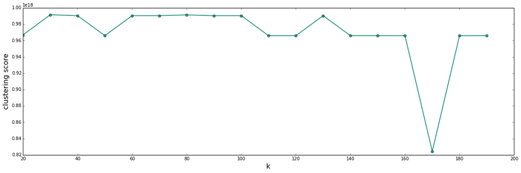

```python
dfScore = pd.DataFrame(scores,columns =['k','SSE'])
DrawFindingKResult(dfScore)
```

K-mean in MLLIB support some parameter we can use to overcome this problem:

- **epsilon** – Distance threshold within which a center will be considered to have converged. If all centers move less than this Euclidean distance, iterations are stopped. (default: 1e-4)
- **runs** – This param has no effect since we are using Spark 2.1. It set numbers of times run for one $k$ and choose the best result. That means we have to implement it for our own in this case.
- Using initialization algorithm as K-means|| which MLMIB support.

```python
for i in range(10):
    clusteringScore(data, k=60, runs=1000)
```

```
k = 60, WSSSE = 9.90680e+17 --- 9.933037281036377 seconds ---
k = 60, WSSSE = 9.90610e+17 --- 11.91524863243103 seconds ---
k = 60, WSSSE = 9.90500e+17 --- 10.231024503707886 seconds ---
k = 60, WSSSE = 1.09430e+18 --- 10.912270784378052 seconds ---
k = 60, WSSSE = 9.93732e+17 --- 11.494505167007446 seconds ---
k = 60, WSSSE = 9.90488e+17 --- 10.17435622215271 seconds ---
k = 60, WSSSE = 9.66155e+17 --- 11.788053512573242 seconds ---
k = 60, WSSSE = 9.90511e+17 --- 10.87873125076294 seconds ---
k = 60, WSSSE = 9.90694e+17 --- 11.01505160331726 seconds ---
k = 60, WSSSE = 9.66043e+17 --- 11.294718742370605 seconds ---
```

```python
for i in range(10):
    clusteringScore(data, k=60, runs=1)
```

```
k = 60, WSSSE = 9.66043e+17 --- 10.273047685623169 seconds ---
k = 60, WSSSE = 9.66153e+17 --- 10.399969100952148 seconds ---
k = 60, WSSSE = 9.90522e+17 --- 10.998721599578857 seconds ---
k = 60, WSSSE = 9.66030e+17 --- 11.315105676651001 seconds ---
k = 60, WSSSE = 9.66047e+17 --- 11.024178981781006 seconds ---
k = 60, WSSSE = 9.90498e+17 --- 10.670417070388794 seconds ---
k = 60, WSSSE = 9.65999e+17 --- 10.684375286102295 seconds ---
k = 60, WSSSE = 9.90812e+17 --- 11.046005249023438 seconds ---
k = 60, WSSSE = 8.24410e+17 --- 10.823117733001709 seconds ---
k = 60, WSSSE = 9.66130e+17 --- 11.392668962478638 seconds ---
```

The experiment above shows that "runs" paramater does not work, the result changes considerably every time we run the algorithm. So we have to implement it by ourself because K-means results are changed based on initialization so we need to run multiple time to obtained the optimal result.

```python
def clusteringScoreWithParam(data, k,initializationMode='random',epsilon=1e-4,maxInt=10,kruns=10):
    WSSSE = np.inf

    print(''.join(['-']*100))
    print("Mode: ",initializationMode,", maxIteration: ", maxInt, ", runs: ", kruns)
    print("k=",k,"RUNNING ",end="")

    start_time = time.time()
    for i in range(kruns):
        print("=",end="")
        clusters = KMeans.train(data, k, maxIterations=maxInt,  initializationMode= initializationMode,epsilon=epsilon)
        # calculate mean square error
        WSSSE_n = clusters.computeCost(data)
        if WSSSE_n < WSSSE:
            WSSSE = WSSSE_n

    print("\t Best WSSSE = %.5e --- %s seconds ---" % (WSSSE,time.time() - start_time))
    return WSSSE
```

```
----------------------------------------------------------------------------------------------------
Mode:  random , maxIteration:  50 , runs:  5
k= 20 RUNNING =====	 Best WSSSE = 6.38395e+17 --- 113.0523886680603 seconds ---
----------------------------------------------------------------------------------------------------
Mode:  random , maxIteration:  50 , runs:  5
k= 30 RUNNING =====	 Best WSSSE = 6.38370e+17 --- 135.3926203250885 seconds ---
----------------------------------------------------------------------------------------------------
Mode:  random , maxIteration:  50 , runs:  5
k= 40 RUNNING =====	 Best WSSSE = 6.38338e+17 --- 141.42958068847656 seconds ---
----------------------------------------------------------------------------------------------------
Mode:  random , maxIteration:  50 , runs:  5
k= 50 RUNNING =====	 Best WSSSE = 6.38347e+17 --- 136.24854493141174 seconds ---
----------------------------------------------------------------------------------------------------
Mode:  random , maxIteration:  50 , runs:  5
k= 60 RUNNING =====	 Best WSSSE = 6.38308e+17 --- 158.90333461761475 seconds ---
----------------------------------------------------------------------------------------------------
Mode:  random , maxIteration:  50 , runs:  5
k= 70 RUNNING =====	 Best WSSSE = 6.38309e+17 --- 171.66615557670593 seconds ---
----------------------------------------------------------------------------------------------------
Mode:  random , maxIteration:  50 , runs:  5
k= 80 RUNNING =====	 Best WSSSE = 6.38307e+17 --- 176.0635793209076 seconds ---
----------------------------------------------------------------------------------------------------
Mode:  random , maxIteration:  50 , runs:  5
k= 90 RUNNING =====	 Best WSSSE = 6.38305e+17 --- 196.1254060268402 seconds ---
----------------------------------------------------------------------------------------------------
Mode:  random , maxIteration:  50 , runs:  5
k= 100 RUNNING =====	 Best WSSSE = 6.38307e+17 --- 196.70927262306213 seconds ---
----------------------------------------------------------------------------------------------------
Mode:  random , maxIteration:  50 , runs:  5
k= 110 RUNNING =====	 Best WSSSE = 6.38306e+17 --- 199.72556734085083 seconds ---
----------------------------------------------------------------------------------------------------
Mode:  random , maxIteration:  50 , runs:  5
k= 120 RUNNING =====	 Best WSSSE = 6.38305e+17 --- 205.1532621383667 seconds ---
----------------------------------------------------------------------------------------------------
Mode:  random , maxIteration:  50 , runs:  5
k= 130 RUNNING =====	 Best WSSSE = 6.38306e+17 --- 223.7124490737915 seconds ---
----------------------------------------------------------------------------------------------------
Mode:  random , maxIteration:  50 , runs:  5
k= 140 RUNNING =====	 Best WSSSE = 6.38305e+17 --- 219.11227822303772 seconds ---
----------------------------------------------------------------------------------------------------
Mode:  random , maxIteration:  50 , runs:  5
k= 150 RUNNING =====	 Best WSSSE = 6.38305e+17 --- 226.02932024002075 seconds ---
----------------------------------------------------------------------------------------------------
Mode:  random , maxIteration:  50 , runs:  5
k= 160 RUNNING =====	 Best WSSSE = 6.38305e+17 --- 239.5817093849182 seconds ---
----------------------------------------------------------------------------------------------------
Mode:  random , maxIteration:  50 , runs:  5
k= 170 RUNNING =====	 Best WSSSE = 6.38303e+17 --- 236.1130712032318 seconds ---
----------------------------------------------------------------------------------------------------
Mode:  random , maxIteration:  50 , runs:  5
k= 180 RUNNING =====	 Best WSSSE = 6.38303e+17 --- 248.2740433216095 seconds ---
----------------------------------------------------------------------------------------------------
Mode:  random , maxIteration:  50 , runs:  5
k= 190 RUNNING =====	 Best WSSSE = 6.38303e+17 --- 254.92057394981384 seconds ---
```

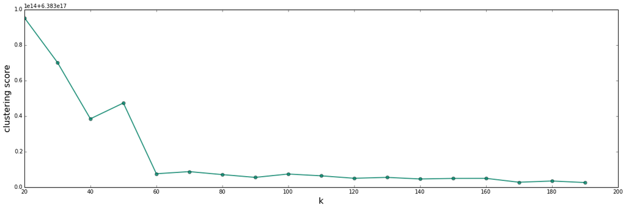

```python
k_range = range(20, 200, 10)
scores = [(k,clusteringScoreWithParam(data, k,'random',1e-5,50,5)) for k in k_range]
dfScore = pd.DataFrame(scores,columns =['k','SSE'])
DrawFindingKResult(dfScore)
```

### 2.2.5 Normalizing features

K-means clustering treats equally all dimensions/directions of the space and therefore tends to produce more or less spherical (rather than elongated) clusters. In this situation, leaving variances uneven is equivalent to putting more weight on variables with smaller variance, so clusters will tend to be separated along variables with greater variance.

In our notebook, since Euclidean distance is used, the clusters will be influenced strongly by the magnitudes of the variables, especially by outliers. Normalizing will remove this bias.

Each feature can be normalized by converting it to a standard score. This means subtracting the mean of the feature’s values from each value, and dividing by the standard deviation

$normalize_i=\frac{feature_i - \mu_i}{\sigma_i}$

Where,

- $normalize_i$ is the normalized value of feature $i$
- $\mu_i$ is the mean of feature $i$
- $\sigma_i$ is the standard deviation of feature $i$

[figure not shown]

#### Question 7

Complete the code below to normalize the data. Print the first 5 lines of the new data.

HINT

If $\sigma_i = 0$ then $normalize_i=feature_i - \mu_i$

```python
def normalizeData(data):
    # number of connections
    n = data.count()

    # calculate means
    means = data.reduce(add) / n

    # calculate the sum square of each feature
    sumSquares = data.map(lambda x: np.power(x-means,2)).reduce(add)/n
    # calculate standard deviation of each feature
    stdevs = np.sqrt(sumSquares)

    # If σ =0 => σ=1
    stdevs[stdevs==0]=1

    def normalize(point):
        return (point-means)/stdevs

    return data.map(normalize)
```

```python
normalizedData = normalizeData(data).cache()
print(normalizedData.take(2))
```

```
[array([ -6.68331854e-02,  -1.72038228e-03,   6.81884351e-02,
        -2.39084686e-03,  -1.51391734e-02,  -1.10348462e-03,
        -2.65207600e-02,  -4.39091558e-03,   2.44279187e+00,
        -2.09732783e-03,  -8.25770840e-03,  -4.54646139e-03,
        -3.28458917e-03,  -9.57233922e-03,  -8.50457842e-03,
        -2.87561127e-02,   0.00000000e+00,  -6.38979005e-04,
        -2.89113034e-02,  -1.57541507e+00,  -1.19624324e+00,
        -4.66042614e-01,  -4.65755574e-01,  -2.48285775e-01,
        -2.48130352e-01,   5.39733093e-01,  -2.56056520e-01,
        -2.01059296e-01,  -3.63913926e+00,  -1.78651044e+00,
        -1.83302273e+00,  -2.82939000e-01,  -1.25793664e+00,
        -1.56668488e-01,  -4.66404784e-01,  -4.65453641e-01,
        -2.50831829e-01,  -2.49631966e-01]), array([ -6.68331854e-02,  -1.77667956e-03,   5.32451452e-03,
        -2.39084686e-03,  -1.51391734e-02,  -1.10348462e-03,
        -2.65207600e-02,  -4.39091558e-03,   2.44279187e+00,
        -2.09732783e-03,  -8.25770840e-03,  -4.54646139e-03,
        -3.28458917e-03,  -9.57233922e-03,  -8.50457842e-03,
        -2.87561127e-02,   0.00000000e+00,  -6.38979005e-04,
        -2.89113034e-02,  -1.57069789e+00,  -1.19217808e+00,
        -4.66042614e-01,  -4.65755574e-01,  -2.48285775e-01,
        -2.48130352e-01,   5.39733093e-01,  -2.56056520e-01,
        -2.01059296e-01,  -3.62351937e+00,  -1.77706870e+00,
         5.98966843e-01,  -2.82939000e-01,   8.21118739e-01,
        -1.56668488e-01,  -4.66404784e-01,  -4.65453641e-01,
        -2.50831829e-01,  -2.49631966e-01])]
```

K-Means uses distance computation at core of its algorithm, distance computation in k-Means weights each dimension equally. If each dimension has different units attached (lb, tons, m, kg ...) then these values aren't really comparable anyway; I give you an example: first figure shows how relative distances inside each dimension (height and weight) for three 2-d observations before and after normalization and the second figure show you euclidence distance between observations before and after normalization.

[figure not shown]

Without normalization, the weights of each dimension are not equal("weight" is heavy than "height in this case) that means it implicitly weights the dimensions and clusters will tend to be separated along variables with greater variance. Common method to equalize dimension is to unit-normalize each dimension individually. In this case we use z-standardizing which is a best-practise to give equal weight to them.  
Other reference for normalization problem: https://www.quora.com/Cluster-analysis/Can-the-choice-of-the-measurement-units-of-the-features-impact-the-clustering/answer/Franck-Dernoncourt

[figure not shown]

#### Question 8

Using the new data, build different models with different values of $k \in [60,70,80,90,100,110]$. Evaluate the results by plotting them and choose the best value of $k$.

```python
k_range = range(60,180,10)
scores = [(k,clusteringScoreWithParam(normalizedData, k,'random',maxInt=70,kruns=8)) for k in k_range]
```

```
----------------------------------------------------------------------------------------------------
Mode:  random , maxIteration:  70 , runs:  8
k= 60 RUNNING ========	 Best WSSSE = 6.08660e+07 --- 383.03608560562134 seconds ---
----------------------------------------------------------------------------------------------------
Mode:  random , maxIteration:  70 , runs:  8
k= 70 RUNNING ========	 Best WSSSE = 6.07075e+07 --- 429.8806917667389 seconds ---
----------------------------------------------------------------------------------------------------
Mode:  random , maxIteration:  70 , runs:  8
k= 80 RUNNING ========	 Best WSSSE = 5.07721e+07 --- 454.3118808269501 seconds ---
----------------------------------------------------------------------------------------------------
Mode:  random , maxIteration:  70 , runs:  8
k= 90 RUNNING ========	 Best WSSSE = 5.24002e+07 --- 526.7251386642456 seconds ---
----------------------------------------------------------------------------------------------------
Mode:  random , maxIteration:  70 , runs:  8
k= 100 RUNNING ========	 Best WSSSE = 5.07723e+07 --- 541.2698795795441 seconds ---
----------------------------------------------------------------------------------------------------
Mode:  random , maxIteration:  70 , runs:  8
k= 110 RUNNING ========	 Best WSSSE = 4.66125e+07 --- 553.9686226844788 seconds ---
----------------------------------------------------------------------------------------------------
Mode:  random , maxIteration:  70 , runs:  8
k= 120 RUNNING ========	 Best WSSSE = 5.05042e+07 --- 611.9689667224884 seconds ---
----------------------------------------------------------------------------------------------------
Mode:  random , maxIteration:  70 , runs:  8
k= 130 RUNNING ========	 Best WSSSE = 5.10858e+07 --- 647.2831816673279 seconds ---
----------------------------------------------------------------------------------------------------
Mode:  random , maxIteration:  70 , runs:  8
k= 140 RUNNING ========	 Best WSSSE = 4.55082e+07 --- 615.262820482254 seconds ---
----------------------------------------------------------------------------------------------------
Mode:  random , maxIteration:  70 , runs:  8
k= 150 RUNNING ========	 Best WSSSE = 4.67589e+07 --- 675.3677680492401 seconds ---
----------------------------------------------------------------------------------------------------
Mode:  random , maxIteration:  70 , runs:  8
k= 160 RUNNING ========	 Best WSSSE = 4.29352e+07 --- 679.8886456489563 seconds ---
----------------------------------------------------------------------------------------------------
Mode:  random , maxIteration:  70 , runs:  8
k= 170 RUNNING ========	 Best WSSSE = 4.58631e+07 --- 728.7721636295319 seconds ---
```

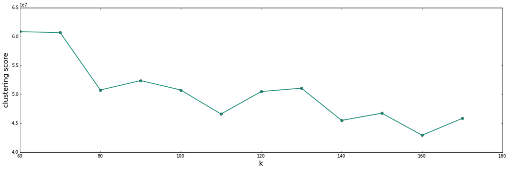

```python
dfScore = pd.DataFrame(scores,columns =['k','SSE'])
DrawFindingKResult(dfScore)
```

[figure not shown]

#### Question 9

Plot the clustering result to see the difference between before and after normalizing features. Discuss about the difference and explain why and if normalization was useful.

```python
def clusteringTraining(data, k,initializationMode='random',epsilon=1e-4,maxInt=10,kruns=10):
    WSSSE = np.inf
    bestClusters = []
    print(''.join(['-']*100))
    print("Mode: ",initializationMode,", maxIteration: ", maxInt, ", runs: ", kruns)
    print("k=",k,"RUNNING ",end="")

    start_time = time.time()
    for i in range(kruns):
        print("=",end="")
        clusters = KMeans.train(data, k, maxIterations=maxInt,  initializationMode= initializationMode,epsilon=epsilon)
        # calculate mean square error
        WSSSE_n = clusters.computeCost(data)
        if WSSSE_n < WSSSE:
            WSSSE = WSSSE_n
            bestClusters = clusters
    print("\t Best WSSSE = %.5e --- %s seconds ---" % (WSSSE,time.time() - start_time))
    return clusters

def ClusterDetail(clusters,data):
    a = clusters.predict(data).collect()
    print(Counter(a))
```

```python
print('------------------------ Before normalization ---------------------------')
clustersUnNorm = clusteringTraining(data, 60,initializationMode='random',maxInt=60,kruns=5)
dfClustersUnNorm = pd.DataFrame(clustersUnNorm.centers)
```

```
------------------------ Before normalization ---------------------------
----------------------------------------------------------------------------------------------------
Mode:  random , maxIteration:  60 , runs:  5
k= 60 RUNNING =====	 Best WSSSE = 6.38306e+17 --- 205.872300863266 seconds ---
```

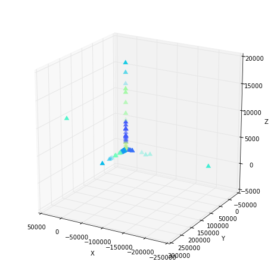

```python
plotClustersDistributedPCA(data, clustersUnNorm, 0.001)
```

```
------------------------ After normalization ---------------------------
----------------------------------------------------------------------------------------------------
Mode:  random , maxIteration:  70 , runs:  6
k= 80 RUNNING ======	 Best WSSSE = 5.74788e+07 --- 323.02650213241577 seconds ---
```

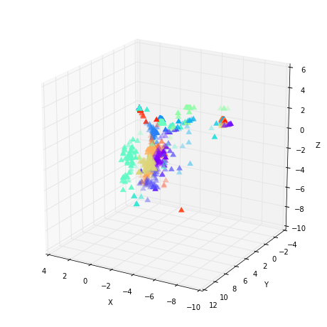

```python
print('------------------------ After normalization ---------------------------')
clustersNorm = clusteringTraining(normalizedData, 80,initializationMode='random',maxInt=70,kruns=6)
dfClustersNorm = pd.DataFrame(clustersNorm.centers)
plotClustersDistributedPCA(normalizedData, clustersNorm, 0.001)
```

Before normalization, some dimensions has a very high variance and range of values. That is the reason why the KMeans algorithm gives a lot more importance to those dimension than the others. As we can see that points are along 3 axes so they are determined only based on one dimension.  
We can see normalized data points reveals a complex structure. The points are spread out many dimension and does not stick into 3 axes as before. it is good because other dimensions now can contribute into the distance if they are different.

```python
sampledData = pd.DataFrame(data.sample(False, 0.0001).collect())
```

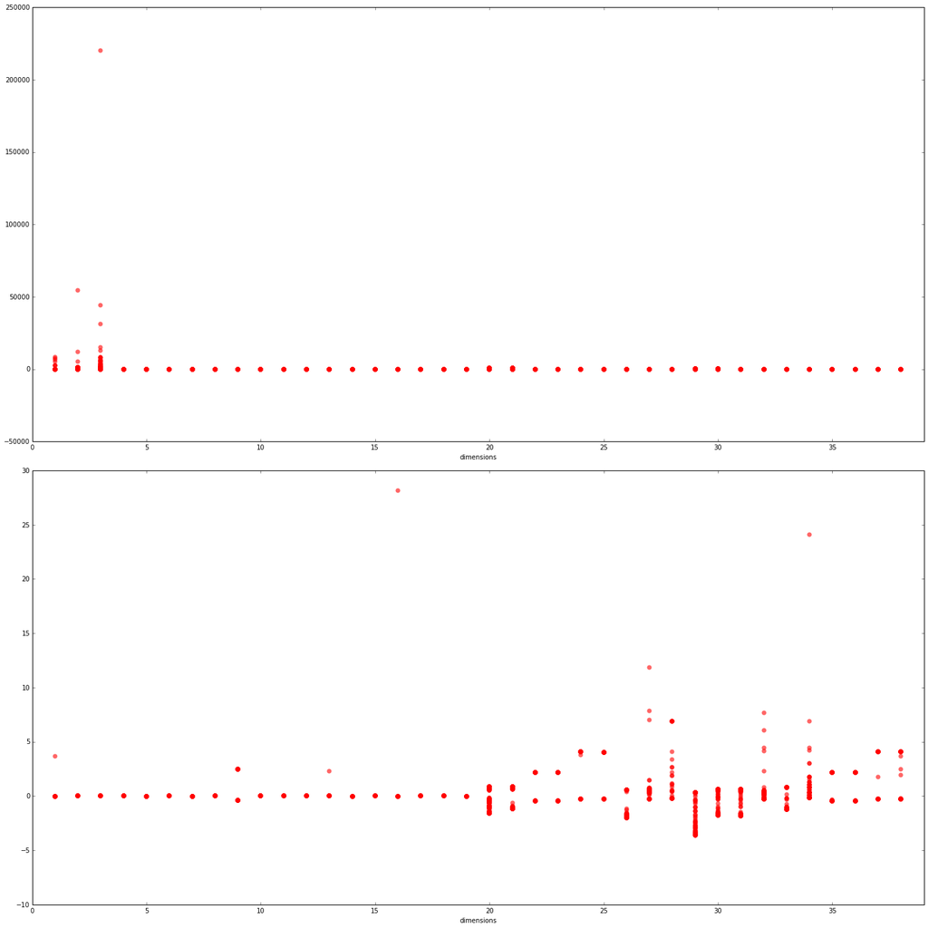

```python
sampledData = pd.DataFrame(data.sample(False, 0.0001).collect())
plt.figure(figsize=(20,20))
ndim = np.shape(sampledData)[1]
nsample = np.shape(sampledData)[0]
# Before normal
plt.subplot(2,1,1)

for i in range(ndim):
    plt.scatter([i+1]*nsample,sampledData[i], alpha=0.6,c='red',s=50,lw=0)

plt.xlim(0,ndim+1)
plt.xlabel("dimensions")

plt.subplot(2,1,2)
sampledData = pd.DataFrame(normalizedData.sample(False, 0.0001).collect())
nsample = np.shape(sampledData)[0]
for i in range(ndim):
    plt.scatter([i+1]*nsample,sampledData[i], alpha=0.6,c='red',s=50,lw=0)

plt.xlim(0,ndim+1)
plt.xlabel("dimensions")
plt.tight_layout()
plt.show()
```

In my opinion, this visualization is better to show how different between dimension before and after normalization. It shows which dimension the points spread out after normalization, which gives the same importance to all the variables. So now they are in same range of value.

## 2.3. Clustering using categorical features

### 2.3.1 Loading data

In the previous section, we ignored the categorical features of our data: this is not a good idea, since these categorical features can be important in providing useful information for clustering. The problem is that K-means (or at least, the one we have developed and the one we use from MLLib) only work with data points in a metric space. Informally, this means that operations such as addition, substraction and computing the mean of data points are trivial and well defined. For a more formal definition of what a metric space is, follow this [link](https://en.wikipedia.org/wiki/Metric_space#Definition).

What we will do next is to transform each categorical features into one or more numerical features. This approach is very widespread: imagine for example you wanted to use K-means to cluster text data. Then, the idea is to transform text data in $d$-dimensional vectors, and a nice way to do it is to use word2vec. If you're interested, follow this link to a nice [blog post](http://bigdatasciencebootcamp.com/posts/Part_3/clustering_news.html) on the problem.

There are two approaches:

- **Approach 1**: mapping **one** categorial feature to **one** numerical feature. The values in each categorical feature are encoded into unique numbers of the new numerical feature. For example, ['VERY HOT','HOT', 'COOL', 'COLD', 'VERY COLD'] will be encoded into [0,1,2,3,4,5]. However, by using this method, we implicit assume that the value of 'VERY HOT' is smaller than 'HOT'... This is not generally true.
- **Approach 2**: mapping mapping **one** categorial feature to **multiple** numerical features. Basically, a single variable with $n$ observations and $d$ distinct values, to $d$ binary variables with $n$ observations each. Each observation indicating the presence (1) or absence (0) of the $d^{th}$ binary variable. For example, ['house', 'car', 'tooth', 'car'] becomes

  ```
  [
  [1,0,0,0],
  [0,1,0,0],
  [0,0,1,0],
  [0,0,0,1],
  ]
  ```

We call the second approach "one-hot encoding". By using this approach, we keep the same role for all values of categorical features.

[figure not shown]

#### Question 10

Calculate the number of distinct categorical features value (at index `1,2,3`). Then construct a new input data using one-hot encoding for these categorical features (don't throw away numerical features!).

```python
def testparseLine(line, k):
    cols = line.split(",")
    return cols[k]

cols1 = np.array(raw_data.map(lambda x: testparseLine(x, 1)).distinct().collect())
cols2 = np.array(raw_data.map(lambda x: testparseLine(x, 2)).distinct().collect())
cols3 = np.array(raw_data.map(lambda x: testparseLine(x, 3)).distinct().collect())

nCol1 = len(cols1)
nCol2 = len(cols2)
nCol3 = len(cols3)

print("CATELORICAL VALUE OF FIRST ATTR: %d values\n"%(nCol1),cols1)
print("\nCATELORICAL VALUE OF SECOND ATTR: %d values\n"%(nCol2),cols2)
print("\nCATELORICAL VALUE OF THIRD ATTR: %d values\n"%(nCol3),cols3)
```

```
CATELORICAL VALUE OF FIRST ATTR: 3 values
 ['udp' 'tcp' 'icmp']

CATELORICAL VALUE OF SECOND ATTR: 70 values
 ['whois' 'pop_3' 'harvest' 'uucp_path' 'other' 'systat' 'ecr_i' 'vmnet'
 'kshell' 'time' 'Z39_50' 'name' 'http' 'tftp_u' 'netbios_dgm' 'remote_job'
 'ftp' 'domain_u' 'discard' 'ldap' 'eco_i' 'finger' 'http_2784' 'private'
 'printer' 'sql_net' 'sunrpc' 'nnsp' 'iso_tsap' 'pop_2' 'exec' 'urp_i'
 'daytime' 'netbios_ns' 'IRC' 'ftp_data' 'urh_i' 'http_443' 'bgp' 'domain'
 'ctf' 'hostnames' 'mtp' 'netstat' 'login' 'klogin' 'nntp' 'ssh' 'imap4'
 'aol' 'efs' 'X11' 'csnet_ns' 'rje' 'smtp' 'telnet' 'tim_i' 'shell'
 'http_8001' 'supdup' 'red_i' 'pm_dump' 'courier' 'echo' 'ntp_u'
 'netbios_ssn' 'uucp' 'gopher' 'auth' 'link']

CATELORICAL VALUE OF THIRD ATTR: 11 values
 ['SH' 'OTH' 'S1' 'REJ' 'S2' 'RSTOS0' 'RSTO' 'S0' 'RSTR' 'S3' 'SF']
```

```python
def getCatelogicalLabel(ar_label,dict_label):
    return dict_label[ar_label.index(1)]
def convertToCatelogicalData(line):
    line = line.tolist()
    idx = 1
    featureOfCol1 = line[idx:idx+nCol1]
    idx+=nCol1
    featureOfCol2 = line[idx:idx+nCol2]
    idx+=nCol2
    featureOfCol3 = line[idx:idx+nCol3]
    idx+=nCol3
    return [getCatelogicalLabel(featureOfCol1,cols1),getCatelogicalLabel(featureOfCol2,cols2),
           getCatelogicalLabel(featureOfCol3,cols3)]+line[idx:]
```

```python
def parseLineWithHotEncoding(line):
    cols = line.split(',')
    # label is the last column
    label = cols[-1]

    vector = cols[:-1]

    # the binary features that are encoded from the first categorial feature
    featureOfCol1 = np.array([0]*nCol1)
    featureOfCol1[cols1==vector[1]] = 1
    # the binary features that are encoded from the second categorial feature
    featureOfCol2 = np.array([0]*nCol2)
    featureOfCol2[cols2==vector[2]] = 1
    # the binary features that are encoded from the third categorial feature
    featureOfCol3 = np.array([0]*nCol3)
    featureOfCol3[cols3==vector[3]] = 1

    # construct the new vector
    vector = np.hstack((vector[0],featureOfCol1,featureOfCol2, featureOfCol3,vector[4:]))

    # convert each value from string to float
    vector = np.array(vector,dtype=float)

    return (label, vector)

labelsAndDataHotEn = raw_data.map(parseLineWithHotEncoding)

dataHotEn= labelsAndDataHotEn.map(lambda x: x[1]).cache()
labelHotEn = labelsAndDataHotEn.map(lambda x: x[0]).cache()
normalizedDataHotEn = normalizeData(dataHotEn).cache()
```

```python
testLabelsAndData, trainLabelsAndData = labelsAndData.randomSplit(weights=[0.3, 0.7])
# we only need the data, not the label
smaller_data = trainLabelsAndData.map(lambda x: x[1]).cache()
smaller_label = trainLabelsAndData.map(lambda x: x[0]).cache()

normalizedSmallerData = normalizeData(smaller_data).cache()
```

### 2.3.2. Building models

[figure not shown]

#### Question 11

Using the new data, cluster the connections with different values of $k \in [80,90,100,110,120,130,140,150,160]$. Evaluate the results and choose the best value of $k$ as previous questions.

```python
k_range = np.arange(80,250,10).tolist()

scores = [(k,clusteringScoreWithParam(normalizedSmallerData, k,'random',maxInt=70,kruns=6)) for k in k_range]

dfScore = pd.DataFrame(scores,columns =['k','SSE'])
```

```
----------------------------------------------------------------------------------------------------
Mode:  random , maxIteration:  70 , runs:  6
k= 80 RUNNING ======	 Best WSSSE = 3.83083e+07 --- 205.7876386642456 seconds ---
----------------------------------------------------------------------------------------------------
Mode:  random , maxIteration:  70 , runs:  6
k= 90 RUNNING ======	 Best WSSSE = 3.87057e+07 --- 243.70358848571777 seconds ---
----------------------------------------------------------------------------------------------------
Mode:  random , maxIteration:  70 , runs:  6
k= 100 RUNNING ======	 Best WSSSE = 3.58020e+07 --- 246.2700936794281 seconds ---
----------------------------------------------------------------------------------------------------
Mode:  random , maxIteration:  70 , runs:  6
k= 110 RUNNING ======	 Best WSSSE = 2.60264e+07 --- 257.09484481811523 seconds ---
----------------------------------------------------------------------------------------------------
Mode:  random , maxIteration:  70 , runs:  6
k= 120 RUNNING ======	 Best WSSSE = 3.02014e+07 --- 276.74201107025146 seconds ---
----------------------------------------------------------------------------------------------------
Mode:  random , maxIteration:  70 , runs:  6
k= 130 RUNNING ======	 Best WSSSE = 2.93474e+07 --- 303.3256788253784 seconds ---
----------------------------------------------------------------------------------------------------
Mode:  random , maxIteration:  70 , runs:  6
k= 140 RUNNING ======	 Best WSSSE = 2.89755e+07 --- 298.3709526062012 seconds ---
----------------------------------------------------------------------------------------------------
Mode:  random , maxIteration:  70 , runs:  6
k= 150 RUNNING ======	 Best WSSSE = 3.19547e+07 --- 308.6050956249237 seconds ---
----------------------------------------------------------------------------------------------------
Mode:  random , maxIteration:  70 , runs:  6
k= 160 RUNNING ======	 Best WSSSE = 2.83119e+07 --- 305.4326915740967 seconds ---
----------------------------------------------------------------------------------------------------
Mode:  random , maxIteration:  70 , runs:  6
k= 170 RUNNING ======	 Best WSSSE = 2.90052e+07 --- 354.0287575721741 seconds ---
----------------------------------------------------------------------------------------------------
Mode:  random , maxIteration:  70 , runs:  6
k= 180 RUNNING ======	 Best WSSSE = 2.56418e+07 --- 353.2660458087921 seconds ---
----------------------------------------------------------------------------------------------------
Mode:  random , maxIteration:  70 , runs:  6
k= 190 RUNNING ======	 Best WSSSE = 2.57296e+07 --- 349.64520239830017 seconds ---
----------------------------------------------------------------------------------------------------
Mode:  random , maxIteration:  70 , runs:  6
k= 200 RUNNING ======	 Best WSSSE = 3.11816e+07 --- 346.3816440105438 seconds ---
----------------------------------------------------------------------------------------------------
Mode:  random , maxIteration:  70 , runs:  6
k= 210 RUNNING ======	 Best WSSSE = 2.80034e+07 --- 359.61379742622375 seconds ---
----------------------------------------------------------------------------------------------------
Mode:  random , maxIteration:  70 , runs:  6
k= 220 RUNNING ======	 Best WSSSE = 2.51782e+07 --- 351.7715368270874 seconds ---
----------------------------------------------------------------------------------------------------
Mode:  random , maxIteration:  70 , runs:  6
k= 230 RUNNING ======	 Best WSSSE = 2.80919e+07 --- 376.1432056427002 seconds ---
----------------------------------------------------------------------------------------------------
Mode:  random , maxIteration:  70 , runs:  6
k= 240 RUNNING ======	 Best WSSSE = 2.09776e+07 --- 367.6704795360565 seconds ---
```

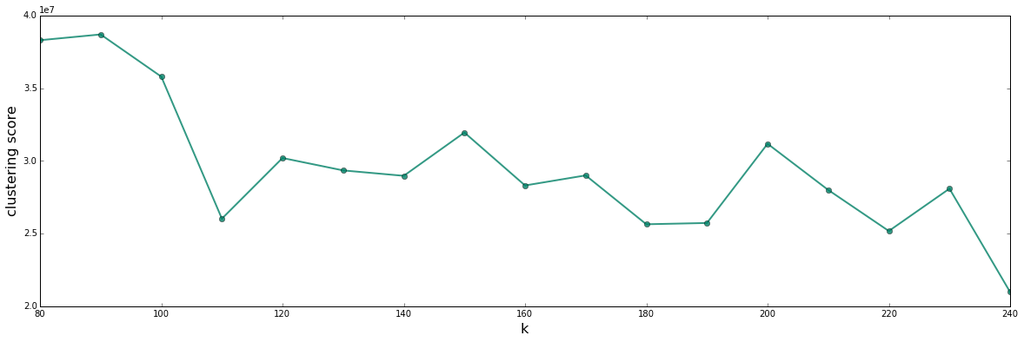

```python
DrawFindingKResult(dfScore)
```

Seem k = 110~120 is the "elbow" and the best value of k we need to find. We should not choose larger k because WSSSE decreases more gradually after that. That means k-means just add more centroids which is not helpful to minimize the distance to its members.  
If you notice, the k is changed when we add data or normalization. Until now, it is just our observation and will try to find out in following session. In addition, in question 13 we will check whether adding more data help us obtain better result or not by entropy metrices. We cannot use WSSSE in this case because our data have different number of dimension so we should not compare the distance that come from 2 different coordination.

## Examine the result in clustering

At the beginning until now, we just examine the result based on the WSSSE metrics. But what do they really happen inside. We will take a look into the result.

```python
from IPython.display import display, HTML
def findClosestClusterRDD(point,clusters):
    predicted = clusters.predict(point[1])
    return (predicted,(point[0],point[1]))
def printWholeDF(df):
    pd.set_option('display.max_rows', len(dfRe))
    display(df)
    pd.reset_option('display.max_rows')
```

We try with the best k for unnormalized data = 60 with 2 different initialization mode and analyse

```python
def dFDetailKmean(predictedData):
    predictedClusterLabelQuantity = predictedData.countByKey()
    predictedClusterLabelDistinctLabel = predictedData.map(lambda x: (x[0],x[1][0])).distinct().countByKey()
    predictedClusterLabelDistinctVector = predictedData.map(lambda x: (x[0],tuple(x[1][1]))).distinct().countByKey()

    a = pd.DataFrame(list(predictedClusterLabelDistinctLabel.items()),
                     columns=['cluster','No of Distinct labels'])
    b = pd.DataFrame(list(predictedClusterLabelQuantity.items()),
                     columns=['cluster','No of elements'])
    c = pd.DataFrame(list(predictedClusterLabelDistinctVector.items()),
                     columns=['cluster','No of Distinct Data points'])
    dfs = [b,c]
    finalDf = a
    for df_ in dfs:
        finalDf = finalDf.merge(df_, on='cluster')
    return finalDf
```

### *K-mean|| initialization mode*

```python
clustersUnNorm = clusteringTraining(data, 60,initializationMode='k-means||',epsilon=1e-4,maxInt=60,kruns=5)
```

```
----------------------------------------------------------------------------------------------------
Mode:  k-means|| , maxIteration:  60 , runs:  5
k= 60 RUNNING =====	 Best WSSSE = 5.29592e+13 --- 107.82396101951599 seconds ---
```

```python
bCentroids = sc.broadcast(clustersUnNorm)
predictedData = labelsAndData.map(lambda x: findClosestClusterRDD(x,bCentroids.value)).cache()
```

```python
finalDf = dFDetailKmean(predictedData)
```

```python
print("Number of centroids", clustersUnNorm.k)
finalDf.sort(columns=['No of elements'],ascending=[0]).reset_index(drop=True).head(20)
```

```
Number of centroids 57
```

|  | cluster | No of Distinct labels | No of elements | No of Distinct Data points |
| --- | --- | --- | --- | --- |
| 0 | 0 | 23 | 4841552 | 972998 |
| 1 | 10 | 8 | 55357 | 52071 |
| 2 | 54 | 1 | 643 | 628 |
| 3 | 24 | 1 | 232 | 232 |
| 4 | 15 | 3 | 198 | 198 |
| 5 | 17 | 1 | 142 | 142 |
| 6 | 14 | 3 | 98 | 98 |
| 7 | 51 | 1 | 60 | 60 |
| 8 | 43 | 1 | 22 | 22 |
| 9 | 22 | 1 | 12 | 12 |
| 10 | 30 | 1 | 11 | 11 |
| 11 | 38 | 1 | 10 | 10 |
| 12 | 39 | 1 | 7 | 7 |
| 13 | 36 | 1 | 7 | 7 |
| 14 | 34 | 1 | 6 | 6 |
| 15 | 35 | 1 | 5 | 5 |
| 16 | 29 | 1 | 5 | 5 |
| 17 | 26 | 1 | 4 | 4 |
| 18 | 32 | 1 | 4 | 4 |
| 19 | 19 | 1 | 4 | 4 |

Using the k-means|| initialization, we obtains lower WSSSE than the random initialization one. Is it good or not? As can be seen from the result of clustering, almost of points is in the cluster 0 and it contains all of classes of our training set. Even we use 60 centroids, but over 50 clusters have only around 10 points. It is not good, because our purpose is try to cluster all of points have same charasteristic (in here they are in same label) in same cluster. So if one clusters contains all of the points, it is not really a good result. in this case, we think Entropy metrics is better evalution metrics for this problem.

### *Random initialization mode*

```python
clustersUnNorm = clusteringTraining(data, 60,initializationMode='random',epsilon=1e-4,maxInt=60,kruns=5)
```

```
----------------------------------------------------------------------------------------------------
Mode:  random , maxIteration:  60 , runs:  5
k= 60 RUNNING =====	 Best WSSSE = 6.38305e+17 --- 158.91614055633545 seconds ---
```

```python
bCentroids = sc.broadcast(clustersUnNorm)
predictedData = labelsAndData.map(lambda x: findClosestClusterRDD(x,bCentroids.value)).cache()
```

```python
finalDf = dFDetailKmean(predictedData)
```

```python
print("Number of centroids", clustersUnNorm.k)
```

```
Number of centroids 41
```

```python
finalDf.sort(columns=['No of elements'],ascending=[0]).reset_index(drop=True).head(20)
```

|  | cluster | No of Distinct labels | No of elements | No of Distinct Data points |
| --- | --- | --- | --- | --- |
| 0 | 2 | 1 | 2278295 | 1786 |
| 1 | 28 | 8 | 404831 | 100139 |
| 2 | 13 | 2 | 339625 | 23 |
| 3 | 35 | 3 | 185535 | 28933 |
| 4 | 4 | 7 | 166964 | 66729 |
| 5 | 23 | 9 | 159696 | 152536 |
| 6 | 3 | 3 | 157920 | 22159 |
| 7 | 19 | 6 | 155764 | 148305 |
| 8 | 14 | 3 | 143552 | 21283 |
| 9 | 6 | 5 | 129975 | 30094 |
| 10 | 0 | 2 | 118061 | 827 |
| 11 | 15 | 10 | 115054 | 110094 |
| 12 | 26 | 4 | 91856 | 13367 |
| 13 | 5 | 9 | 84783 | 83289 |
| 14 | 22 | 2 | 70285 | 162 |
| 15 | 20 | 6 | 66091 | 64270 |
| 16 | 30 | 15 | 59692 | 49053 |
| 17 | 7 | 5 | 49713 | 48337 |
| 18 | 17 | 2 | 25895 | 9542 |
| 19 | 9 | 5 | 21724 | 20802 |

Even random initialization mode obtain worse error, it seems the cluster is better than previous one, cluster 2 have 2.2 million point but has only one label inside cluster. In addition, data points spread over clusters and each of them contains around 2 3 distinct labels.  
The third column shows you how many distinct point inside 1 cluster, cluster 2 have 2.2 million elements which belong to only 1 class but it has only 1786 distinct points that means there are lot of identical points in 1 class, another example is cluster 13 which has 339625 elements belonging to 2 classes and only 23 distinct points.  
However, there are some bad clusters, cluster 15 contains 10 different label and cluster 30 contains 15 different labels. It can be only some mis-clustering point in that cluster, we will check by using entropy metrices later to clarify our result.

Now, we try random mode for both normalized data with and without categorical data. The best k for each as we obtain from previous questions.

```python
def normalizeLabelAndData(labelAndData):
    # number of connections
    data = labelAndData.values()
    n = labelAndData.count()

    # calculate means
    means = data.reduce(add) / n

    # calculate the sum square of each feature
    sumSquares = data.map(lambda x: np.power(x-means,2)).reduce(add)/n
    # calculate standard deviation of each feature
    stdevs = np.sqrt(sumSquares)

    # If σ =0 => σ=1
    stdevs[stdevs==0]=1

    def normalize(point):
        return (point-means)/stdevs

    return labelAndData.map(lambda x: (x[0],normalize(x[1])))
```

```python
clustersNorm = clusteringTraining(normalizedData, 110,initializationMode='random',epsilon=1e-4,maxInt=70,kruns=5)
```

```
----------------------------------------------------------------------------------------------------
Mode:  random , maxIteration:  70 , runs:  5
k= 110 RUNNING =====	 Best WSSSE = 4.21577e+07 --- 326.0517930984497 seconds ---
```

```python
normalizedLabelAndData = normalizeLabelAndData(labelsAndData).cache()
```

```python
bCentroids = sc.broadcast(clustersNorm)
predictedDataNorm = normalizedLabelAndData.map(lambda x: findClosestClusterRDD(x,bCentroids.value)).cache()
finalDfNorm = dFDetailKmean(predictedDataNorm)
```

```python
print("Number of centroids", clustersUnNorm.k)
```

```
Number of centroids 41
```

```python
finalDfNorm = finalDfNorm.sort(columns=['No of elements'],ascending=[0]).reset_index(drop=True)
finalDfNorm.head(25)
```

|  | cluster | No of Distinct labels | No of elements | No of Distinct Data points |
| --- | --- | --- | --- | --- |
| 0 | 6 | 2 | 2613978 | 436 |
| 1 | 21 | 5 | 239727 | 238566 |
| 2 | 4 | 4 | 206626 | 31397 |
| 3 | 51 | 3 | 201776 | 180047 |
| 4 | 8 | 1 | 137716 | 28630 |
| 5 | 30 | 2 | 127076 | 27100 |
| 6 | 48 | 2 | 119408 | 693 |
| 7 | 2 | 1 | 101574 | 27499 |
| 8 | 9 | 1 | 89888 | 18687 |
| 9 | 50 | 1 | 72952 | 13239 |
| 10 | 7 | 1 | 71424 | 12689 |
| 11 | 11 | 2 | 70557 | 166 |
| 12 | 18 | 11 | 61827 | 61656 |
| 13 | 37 | 1 | 60484 | 8982 |
| 14 | 42 | 4 | 58073 | 56699 |
| 15 | 26 | 2 | 57594 | 7372 |
| 16 | 27 | 1 | 56863 | 12962 |
| 17 | 14 | 4 | 52906 | 52797 |
| 18 | 46 | 1 | 47982 | 1866 |
| 19 | 22 | 2 | 47761 | 5910 |
| 20 | 38 | 1 | 45197 | 5782 |
| 21 | 13 | 5 | 40840 | 26244 |
| 22 | 0 | 10 | 40362 | 17656 |
| 23 | 19 | 9 | 35261 | 35143 |
| 24 | 29 | 1 | 27546 | 10399 |

```python
predictClusClass = predictedDataNorm.map(lambda x: ((x[0],x[1][0]),1)).reduceByKey(add).map(lambda x: (x[0][0],x[0][1],x[1]))
```

```python
dfClusterClasses = pd.DataFrame(predictClusClass.collect(),columns=['cluster','class','classCount'])
getClusterCount = dfClusterClasses.groupby('cluster').sum().classCount
dfClusterClasses['clusterCount'] = dfClusterClasses.cluster.apply(getClusterCount.get_value)
dfClusterClasses = dfClusterClasses.sort(columns=['clusterCount','classCount'],ascending=[0,0]).reset_index(drop=True)
```

```python
dfClusterClasses[dfClusterClasses.cluster==6]
```

|  | cluster | class | classCount | clusterCount |
| --- | --- | --- | --- | --- |
| 0 | 6 | smurf. | 2613971 | 2613978 |
| 1 | 6 | normal. | 7 | 2613978 |

```python
dfClusterClasses[dfClusterClasses.cluster==18]
```

|  | cluster | class | classCount | clusterCount |
| --- | --- | --- | --- | --- |
| 25 | 18 | normal. | 61250 | 61827 |
| 26 | 18 | back. | 415 | 61827 |
| 27 | 18 | warezclient. | 132 | 61827 |
| 28 | 18 | buffer_overflow. | 9 | 61827 |
| 29 | 18 | satan. | 8 | 61827 |
| 30 | 18 | loadmodule. | 4 | 61827 |
| 31 | 18 | perl. | 3 | 61827 |
| 32 | 18 | portsweep. | 2 | 61827 |
| 33 | 18 | rootkit. | 2 | 61827 |
| 34 | 18 | multihop. | 1 | 61827 |
| 35 | 18 | imap. | 1 | 61827 |

```python
dfClusterClasses[dfClusterClasses.cluster==21]
```

|  | cluster | class | classCount | clusterCount |
| --- | --- | --- | --- | --- |
| 2 | 21 | normal. | 239421 | 239727 |
| 3 | 21 | warezclient. | 301 | 239727 |
| 4 | 21 | buffer_overflow. | 3 | 239727 |
| 5 | 21 | ftp_write. | 1 | 239727 |
| 6 | 21 | rootkit. | 1 | 239727 |

With WSSSE metrices, we cannot say anything about result with and without normalization. Because after we normalize, the range of value in each dimension is not the same so that we cannot use distance to compare 2 models. We only have some overview that it is quite good in clustering because there are lots of clusters which contains only data from 1 or 2 classes.  
3 tables above shows you the occurences of class on cluster 6 (most numbers of element), 18 (most difference classes), and cluster 21. Even we have more classes in one cluster but number of points in "noisy" classes are much smaller than the class which has largest number of points.  
Later in question 13, we will use entropy to clarify the goodness between normalization and non-normalization.

```python
a = dfClusterClasses[dfClusterClasses['class']=='smurf.']
b = finalDfNorm[finalDfNorm.cluster.isin(a.cluster)]
a.merge(b).drop(['No of elements','No of Distinct Data points'],axis=1)
```

|  | cluster | class | classCount | clusterCount | No of Distinct labels |
| --- | --- | --- | --- | --- | --- |
| 0 | 6 | smurf. | 2613971 | 2613978 | 2 |
| 1 | 48 | smurf. | 119218 | 119408 | 2 |
| 2 | 11 | smurf. | 70526 | 70557 | 2 |
| 3 | 44 | smurf. | 80 | 20709 | 12 |
| 4 | 3 | smurf. | 174 | 14015 | 9 |
| 5 | 16 | smurf. | 2937 | 4734 | 4 |
| 6 | 10 | smurf. | 980 | 1058 | 2 |

'smurf' is a class has most data points. From the table, we can see it has 4 clusters in kmeans (6,48,11,10) because it has major number of points in those cluster. Other clusters (44,3), 'smurf' is likely "noisy" point those cluster.

## 2.4. Anomaly detection

When we have a new connection data (e.g., one that we never saw before), we simply find the closest cluster for it, and use this information as a proxy to indicate whether the data point is anomalous or not. A simple approach to decide wheter there is an anomaly or not, amounts to measuring the new data point’s distance to its nearest centroid. If this distance exceeds some thresholds, it is anomalous.

[figure not shown]

#### Question 12

Build your model with the best value of $k$ in your opinion. Then, detect the anomalous connections in our data. Plot and discuss your result.

HINT

The threshold has strong impact on the result. Be careful when choosing it! A simple way to choose the threshold's value is picking up a distance of a data point from among known data. For example, the 100th-farthest data point distance can be an option.

## Some Comment

Our goal is to detect threats which may be the one that has never been detected and classified yet in our dataset. To get further investigation, we try to detect anomalies in network inside our dataset that means we do not have the ground truth after we detect anomalies whether the connection we detect is an attack or normal.

```python
clusters = clusteringTraining(normalizedDataHotEn, 110,'random',maxInt=70,kruns=6)
```

```
----------------------------------------------------------------------------------------------------
Mode:  random , maxIteration:  70 , runs:  6
k= 110 RUNNING ======	 Best WSSSE = 2.79363e+08 --- 416.958607673645 seconds ---
```

```python
# Evaluate clustering by computing Within Set Sum of Squared Errors
def euclidean_distance(a, b):
    c = a - b
    return np.sqrt(c.T.dot(c))

def distanceToCentroid(clusters, point):
    closest_center = clusters.centers[clusters.predict(point)]
    return euclidean_distance(closest_center,point)
```

```python
bClusters = sc.broadcast(clusters)
score = normalizedDataHotEn.map(lambda point: (point, distanceToCentroid(bClusters.value, point)))
```

```python
anormalyPoint = score.takeOrdered(100, key=lambda x: -x[1])
print("Threshold for clusters:", anormalyPoint[-1][1])
print("Higest distance in our dataset:",anormalyPoint[0][1])
```

```
Threshold for clusters: 320.56298553
Higest distance in our dataset: 2677.59876292
```

We build our model with k = 110, using both numberical and categorical after normalization  
We can see that the largest distance from a point to its closest center is: 2677.598. We choose the distance from 100th-farthest data point to its closest center to become our threashold. In this case threshold = 320.562  
If the distance of a new data point to its closest center bigger than the threshold, it is anomalous and need to be had further investigation.

```python
def FindPCADim(data):
    pca = PCA(copy=True, n_components=3, whiten=False)
    pca.fit(data)
    return pca

def PlotDataInto3D(data, Ylabels,pca,elev=20,azim=120):
    colors = iter(cm.rainbow(np.linspace(0, 1, len(np.unique(Ylabels)))))

    # Using PCA to reduce dimension into 3

    dataNewDim = np.asarray(pca.transform(data))

    #plot the clusters in color
    fig = plt.figure(figsize=(8, 8))
    ax = fig.add_subplot(111, projection='3d')

    for i in set(Ylabels):
        idx = np.where(Ylabels == i)
        curData = dataNewDim[idx]

        ax.scatter(curData[:,0],curData[:,1], curData[:,2],
                   color=next(colors),cmap=plt.cm.bwr,marker=(3, 0),lw = 0,s=100,label='custer %d'%(i))

        ax.view_init(elev=elev,azim=azim)

    ax.set_xlabel('X')
    ax.set_ylabel('Y')
    ax.set_zlabel('Z')

    return ax
```

```python
dataNewDim = np.asarray(pca_model.transform(anormalPoint)).T
```

#### *Visualize center of each clusters*

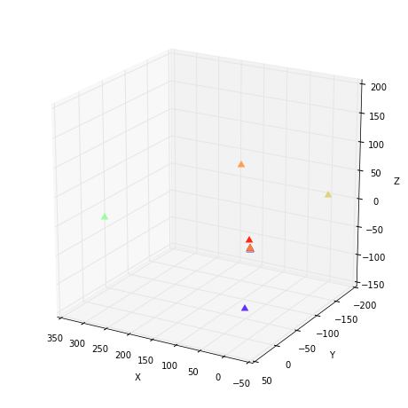

```python
pca_model = FindPCADim(clusters.centers)
PlotDataInto3D(clusters.centers,np.arange(len(clusters.centers)),pca_model)
```

#### *Visualize 100 anomaly points*

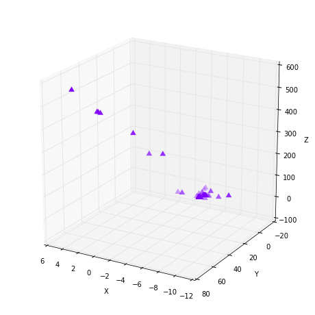

```python
anormalPoint = list(map(lambda x: x[0],anormalyPoint))
PlotDataInto3D(anormalPoint,np.array([0]*len(anormalPoint)),pca_model)
```

#### *Visualize center of each clusters and 100 anomaly points*

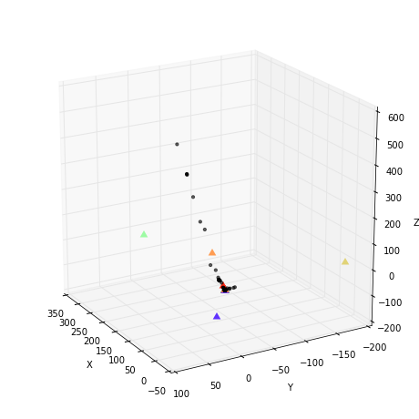

```python
ax = PlotDataInto3D(clusters.centers,np.arange(len(clusters.centers)),pca_model,azim=150)

anormalPoint = list(map(lambda x: x[0],anormalyPoint))
dataNewDim = np.asarray(pca_model.transform(anormalPoint)).T
ax.scatter(dataNewDim[0],dataNewDim[1], dataNewDim[2],
                   color='black',marker='o',alpha=0.6,lw = 1,s=10)
```

If we compare 2 picture, all of the points that outsides the the most dense area (250,-100,-200) seem very far away from all centroids. One of the reason that you see they are too close because we only visualize in 3-dimensions which is reduced from 122 dimensions. This picture just give you an overview of relationship between our anomaly points and centroids

```python
normalizedLabelAndDataHotEn = normalizeLabelAndData(labelsAndDataHotEn).cache()
```

```python
bCentroids = sc.broadcast(clusters)
predictedDataNorm = normalizedLabelAndDataHotEn.map(lambda x: findClosestClusterRDD(x,bCentroids.value)).cache()
```

```python
clusterLabelList = list(predictedDataNorm.countByKey().items())
```

```python
dfClusterLabelList = pd.DataFrame(list(map(lambda x: (x[0][0],x[0][1],x[1]),clusterLabelList)),
                                  columns=['cluster','label','classCount'])
clusterList =  dfClusterLabelList.groupby('cluster')[['classCount']].sum()['classCount']
```

```python
dfClusterLabelList['clusterCount'] = dfClusterLabelList.cluster.apply(clusterList.get_value)
dfClusterLabelList.sort(columns=['clusterCount','classCount'],ascending=[1,0]).reset_index(drop=True).head(29)
```

|  | cluster | label | classCount | clusterCount |
| --- | --- | --- | --- | --- |
| 0 | 34 | normal. | 46 | 50 |
| 1 | 34 | guess_passwd. | 2 | 50 |
| 2 | 34 | satan. | 1 | 50 |
| 3 | 34 | warezclient. | 1 | 50 |
| 4 | 48 | normal. | 69 | 121 |
| 5 | 48 | guess_passwd. | 50 | 121 |
| 6 | 48 | satan. | 1 | 121 |
| 7 | 48 | rootkit. | 1 | 121 |
| 8 | 42 | normal. | 129 | 135 |
| 9 | 42 | satan. | 6 | 135 |
| 10 | 4 | normal. | 153 | 161 |
| 11 | 4 | back. | 5 | 161 |
| 12 | 4 | satan. | 2 | 161 |
| 13 | 4 | warezclient. | 1 | 161 |
| 14 | 18 | pod. | 259 | 268 |
| 15 | 18 | teardrop. | 9 | 268 |
| 16 | 58 | normal. | 302 | 334 |
| 17 | 58 | buffer_overflow. | 18 | 334 |
| 18 | 58 | phf. | 4 | 334 |
| 19 | 58 | loadmodule. | 3 | 334 |
| 20 | 58 | perl. | 3 | 334 |
| 21 | 58 | rootkit. | 2 | 334 |
| 22 | 58 | multihop. | 2 | 334 |
| 23 | 43 | normal. | 489 | 493 |
| 24 | 43 | back. | 2 | 493 |
| 25 | 43 | satan. | 1 | 493 |
| 26 | 43 | imap. | 1 | 493 |
| 27 | 37 | normal. | 518 | 519 |
| 28 | 37 | satan. | 1 | 519 |

[figure not shown]

#### Question 13

Try other methods to find the best value for $k$ such as `silhouette`, `entropy`... In particular, with this data, you can take advantage of predefined labels to calculate the quality of model using entropy... However, we suggest you to try with `silhouette`. It's more general and can work with any dataset (with and without predefined labels).

Here are some additional information about the metrics we suggest to use:

- Silhouette)
- [Hack approach to Silhouette](http://scikit-learn.org/stable/auto_examples/cluster/plot_kmeans_silhouette_analysis.html)
- [Entropy](http://scikit-learn.org/stable/modules/clustering.html) [Lookup for entropy]

Note

you are free to play with any relevant evaluation metric you think appropriate for your work!

## ENTROPY MEASUREMENT

Using Sum Square Error, we still do not use given label data, which is useful information to check the quality of clustering. So if it is a good clustering, it only contains one or few types of the known attacks and little of anything else. Using entropy we can check the purity of the cluster as measurement for quality of clustering

```python
def entropy(labelCount,nPoint):
    p = labelCount/nPoint
    return -p*np.log2(p)

def findClosestClusterRDD(point,clusters):
    predicted = clusters.predict(point[1])
    return ((predicted,point[0]),1)

def measureEntropy(data,clusters):
    # training
    bCentroids = sc.broadcast(clusters)

    # prediction
    predictedData = data.map(lambda x: findClosestClusterRDD(x,bCentroids.value))

    # n of points in each labels of the cluster
    predictedDataByCluster = predictedData.reduceByKey(add).cache()

    # n Of points in each clusters:
    clustersCount = predictedDataByCluster.map(lambda line: (line[0][0],line[1])).reduceByKey(add).collect()
    clusterCountDict = {key: value for key, value in clustersCount}
    bClusterCountDict = sc.broadcast(clusterCountDict)

    # entropy for each label of the cluster
    clustersEntropy = predictedDataByCluster.map(
        lambda line: (line[0][0],entropy(line[1],bClusterCountDict.value[line[0][0]]))).reduceByKey(add)

    # find final entropy with weight each cluster
    clustersEntropyWeight = clustersEntropy.map(lambda line: np.array(
                (line[1]*bClusterCountDict.value[line[0]], bClusterCountDict.value[line[0]])))

    TotalScore = clustersEntropyWeight.reduce(add)
    return TotalScore[0]/TotalScore[1]

def bestValueEntropy(measureValue,bestMeasureValue):
    if measureValue < bestMeasureValue:
            return True
    return False
```

```python
normalizedLabelAndDataHotEn = normalizeLabelAndData(labelsAndDataHotEn).cache() #.sample(False,0.7)
normalizedLabelAndData = normalizeLabelAndData(labelsAndData).cache()
```

### *Entropy implementation version* - parallel

I this version, i find entropy of the models in parallel. First, we find clusters which data belongs and compute number of points in each cluster and broadcast it. Then we count number of occurances in each group (ClusterID,Class). After that, we compute entropy for each clusters then compute entropy of the model

##### k-means initialization

```python
clustersUnNorm = clusteringTraining(data, 60,initializationMode='k-means||',epsilon=1e-4,maxInt=60,kruns=5)
print("Entropy =",measureEntropy(labelsAndData,clustersUnNorm))
```

```
----------------------------------------------------------------------------------------------------
Mode:  k-means|| , maxIteration:  60 , runs:  5
k= 60 RUNNING =====	 Best WSSSE = 3.74495e+13 --- 123.36220526695251 seconds ---
Entropy = 1.48681262406
```

##### random initialization

```python
clustersUnNorm = clusteringTraining(data, 60,initializationMode='random',epsilon=1e-4,maxInt=60,kruns=5)
print("Entropy =",measureEntropy(labelsAndData,clustersUnNorm))
```

```
----------------------------------------------------------------------------------------------------
Mode:  random , maxIteration:  60 , runs:  5
k= 60 RUNNING =====	 Best WSSSE = 6.38306e+17 --- 175.87853741645813 seconds ---
Entropy = 0.142184277833
```

This experiment shows that WSSSE metrics is not helpful for this problem. As we mentioned, k-means initialization give us smaller WSSSE than random initialization but the its entropy is much larger than random ones. The entropy is high that means your cluster is not pure and contains lots of distorters. So lower entropy that means number of points of defined class dominate in the cluster so it is good because we want all of the points which have same characteristic (label) are in same cluster. In this metrices, we also use label of data, which is not used by WSSSE, to evaluate our result. From what we analysed, entropy is better metrics to evaluate in this problem.

##### numberical data with normalization

```python
clustersNorm = clusteringTraining(normalizedData, 80,initializationMode='random',maxInt=70,kruns=5)
print("Entropay =",measureEntropy(normalizedLabelAndData,clustersNorm))
```

```
----------------------------------------------------------------------------------------------------
Mode:  random , maxIteration:  70 , runs:  5
k= 80 RUNNING =====	 Best WSSSE = 5.62486e+07 --- 279.7315933704376 seconds ---
Entropay = 0.0503921893188
```

##### numberical and categorical data with normalization

```python
clustersNorm = clusteringTraining(normalizedDataHotEn, 110,initializationMode='random',epsilon=1e-4,maxInt=70,kruns=5)
print("Entropay =",measureEntropy(normalizedLabelAndDataHotEn,clustersNorm))
```

```
----------------------------------------------------------------------------------------------------
Mode:  random , maxIteration:  70 , runs:  5
k= 110 RUNNING =====	 Best WSSSE = 2.91925e+08 --- 497.4018349647522 seconds ---
Entropay = 0.0275542683784
```

This experiment just want to show using more data help us cluster better. As you can see that even the WSSSE of the model using both numberical and categorical data is larger than only using numberical data but we obtain lower entropy that show us its cluster is more pure than the model only use numberical data.  
However, the running time in the model using full dimension of data (122 dimensions) is much longer than one only use numberical data (38 dimension), correspondingly 500 seconds and 280 seconds.

## Using entropy to find best k

```python
def clusteringScoreEntropy(data,k,initializationMode='random',epsilon=1e-4,maxIterations=10,kruns=1):
    bestMeasureValue = np.inf
    bestClusters = []

    print(''.join(['-']*100))
    print("Mode: ",initializationMode,", maxIteration: ", maxIterations, ", runs: ", kruns)
    print("k=",k,"RUNNING ",end="")

    start_time = time.time()

    for i in range(kruns):
        print("=",end="")
        clusters = KMeans.train(data.values(), k, maxIterations=maxIterations,  initializationMode= initializationMode,epsilon=epsilon)

        # calculate measure value
        measureValue = measureEntropy(data,clusters)
        if bestValueEntropy(measureValue,bestMeasureValue):
            bestMeasureValue = measureValue
            bestClusters = clusters

    print("\t Best Entropy = %f --- %s seconds ---" % (bestMeasureValue,time.time() - start_time))

    return bestMeasureValue
```

##### numberical data without normalization

```
----------------------------------------------------------------------------------------------------
Mode:  random , maxIteration:  70 , runs:  5
k= 20 RUNNING =====	 Best Entropy = 0.555503 --- 363.881756067276 seconds ---
----------------------------------------------------------------------------------------------------
Mode:  random , maxIteration:  70 , runs:  5
k= 30 RUNNING =====	 Best Entropy = 0.349244 --- 436.1315929889679 seconds ---
----------------------------------------------------------------------------------------------------
Mode:  random , maxIteration:  70 , runs:  5
k= 40 RUNNING =====	 Best Entropy = 0.165775 --- 480.56758069992065 seconds ---
----------------------------------------------------------------------------------------------------
Mode:  random , maxIteration:  70 , runs:  5
k= 50 RUNNING =====	 Best Entropy = 0.175945 --- 505.55582785606384 seconds ---
----------------------------------------------------------------------------------------------------
Mode:  random , maxIteration:  70 , runs:  5
k= 60 RUNNING =====	 Best Entropy = 0.125049 --- 600.3000898361206 seconds ---
----------------------------------------------------------------------------------------------------
Mode:  random , maxIteration:  70 , runs:  5
k= 70 RUNNING =====	 Best Entropy = 0.055533 --- 629.8463711738586 seconds ---
----------------------------------------------------------------------------------------------------
Mode:  random , maxIteration:  70 , runs:  5
k= 80 RUNNING =====	 Best Entropy = 0.046198 --- 705.9214606285095 seconds ---
----------------------------------------------------------------------------------------------------
Mode:  random , maxIteration:  70 , runs:  5
k= 90 RUNNING =====	 Best Entropy = 0.044708 --- 746.6426475048065 seconds ---
----------------------------------------------------------------------------------------------------
Mode:  random , maxIteration:  70 , runs:  5
k= 100 RUNNING =====	 Best Entropy = 0.044575 --- 808.0551588535309 seconds ---
----------------------------------------------------------------------------------------------------
Mode:  random , maxIteration:  70 , runs:  5
k= 110 RUNNING =====	 Best Entropy = 0.043422 --- 881.1616811752319 seconds ---
----------------------------------------------------------------------------------------------------
Mode:  random , maxIteration:  70 , runs:  5
k= 120 RUNNING =====	 Best Entropy = 0.042799 --- 930.2825379371643 seconds ---
```

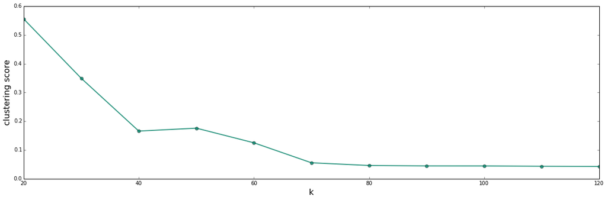

```python
k_range = np.arange(20,130,10).tolist()
scores = [(k,clusteringScoreEntropy(labelsAndData, k,'random',maxIterations=70,kruns=5)) for k in k_range]
dfScore = pd.DataFrame(scores,columns =['k','SSE'])
DrawFindingKResult(dfScore)
```

Following this paper: http://corescholar.libraries.wright.edu/cgi/viewcontent.cgi?article=1177&context=knoesis (looking at the figure 3) we found that entropy of the model will decrease when increasing k. In our graph, entropy as k=40 is smaller than k=50, as we explained before this is just a failure of centroids initialization. Running 5 times for each k may be not enough to find the best cluster.  
To conclude the best, we will use similar method that using "elbow" of the graph. In this case, the best k = 70 which is close to the best k we obtained before (k=60).

##### numberical data with normalization

```
----------------------------------------------------------------------------------------------------
Mode:  random , maxIteration:  70 , runs:  5
k= 60 RUNNING =====	 Best Entropy = 0.026707 --- 389.7988085746765 seconds ---
----------------------------------------------------------------------------------------------------
Mode:  random , maxIteration:  70 , runs:  5
k= 70 RUNNING =====	 Best Entropy = 0.023477 --- 429.93701910972595 seconds ---
----------------------------------------------------------------------------------------------------
Mode:  random , maxIteration:  70 , runs:  5
k= 80 RUNNING =====	 Best Entropy = 0.022939 --- 483.80904150009155 seconds ---
----------------------------------------------------------------------------------------------------
Mode:  random , maxIteration:  70 , runs:  5
k= 90 RUNNING =====	 Best Entropy = 0.022453 --- 526.0393536090851 seconds ---
----------------------------------------------------------------------------------------------------
Mode:  random , maxIteration:  70 , runs:  5
k= 100 RUNNING =====	 Best Entropy = 0.022625 --- 544.6678841114044 seconds ---
----------------------------------------------------------------------------------------------------
Mode:  random , maxIteration:  70 , runs:  5
k= 110 RUNNING =====	 Best Entropy = 0.018411 --- 655.6450624465942 seconds ---
----------------------------------------------------------------------------------------------------
Mode:  random , maxIteration:  70 , runs:  5
k= 120 RUNNING =====	 Best Entropy = 0.021288 --- 632.7927069664001 seconds ---
----------------------------------------------------------------------------------------------------
Mode:  random , maxIteration:  70 , runs:  5
k= 130 RUNNING =====	 Best Entropy = 0.018903 --- 699.1551368236542 seconds ---
----------------------------------------------------------------------------------------------------
Mode:  random , maxIteration:  70 , runs:  5
k= 140 RUNNING =====	 Best Entropy = 0.017840 --- 734.1456899642944 seconds ---
----------------------------------------------------------------------------------------------------
Mode:  random , maxIteration:  70 , runs:  5
k= 150 RUNNING =====	 Best Entropy = 0.016513 --- 811.2271678447723 seconds ---
```

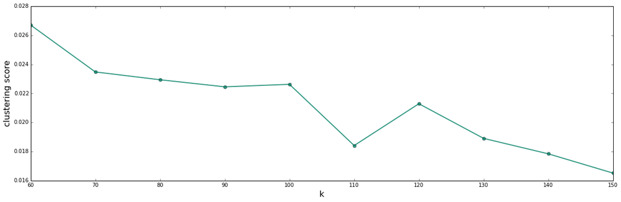

```python
k_range = np.arange(60,160,10).tolist()
scores = [(k,clusteringScoreEntropy(normalizedLabelAndData, k,'random',maxIterations=70,kruns=5)) for k in k_range]
dfScore = pd.DataFrame(scores,columns =['k','SSE'])
DrawFindingKResult(dfScore)
```

In this case, it is harder to make the conclusion because value of entropy reduce slowly at the the beginning. Because the dramatical drop at the k = 110. We believe that our best k is around (100-110) which is not close to our best k from WSSSE metrics (k=80).

##### numberical and categorical data with normalization

```
----------------------------------------------------------------------------------------------------
Mode:  random , maxIteration:  70 , runs:  5
k= 80 RUNNING =====	 Best Entropy = 0.030301 --- 527.2867424488068 seconds ---
----------------------------------------------------------------------------------------------------
Mode:  random , maxIteration:  70 , runs:  5
k= 90 RUNNING =====	 Best Entropy = 0.028648 --- 523.9602453708649 seconds ---
----------------------------------------------------------------------------------------------------
Mode:  random , maxIteration:  70 , runs:  5
k= 100 RUNNING =====	 Best Entropy = 0.025322 --- 536.3817410469055 seconds ---
----------------------------------------------------------------------------------------------------
Mode:  random , maxIteration:  70 , runs:  5
k= 110 RUNNING =====	 Best Entropy = 0.025453 --- 633.319821357727 seconds ---
----------------------------------------------------------------------------------------------------
Mode:  random , maxIteration:  70 , runs:  5
k= 120 RUNNING =====	 Best Entropy = 0.025743 --- 705.5510356426239 seconds ---
----------------------------------------------------------------------------------------------------
Mode:  random , maxIteration:  70 , runs:  5
k= 130 RUNNING =====	 Best Entropy = 0.024402 --- 846.4366648197174 seconds ---
----------------------------------------------------------------------------------------------------
Mode:  random , maxIteration:  70 , runs:  5
k= 140 RUNNING =====	 Best Entropy = 0.024626 --- 881.3457305431366 seconds ---
----------------------------------------------------------------------------------------------------
Mode:  random , maxIteration:  70 , runs:  5
k= 150 RUNNING =====	 Best Entropy = 0.024160 --- 884.0900917053223 seconds ---
----------------------------------------------------------------------------------------------------
Mode:  random , maxIteration:  70 , runs:  5
k= 160 RUNNING =====	 Best Entropy = 0.021426 --- 913.8223705291748 seconds ---
----------------------------------------------------------------------------------------------------
Mode:  random , maxIteration:  70 , runs:  5
k= 170 RUNNING =====	 Best Entropy = 0.020871 --- 1054.7201266288757 seconds ---
```

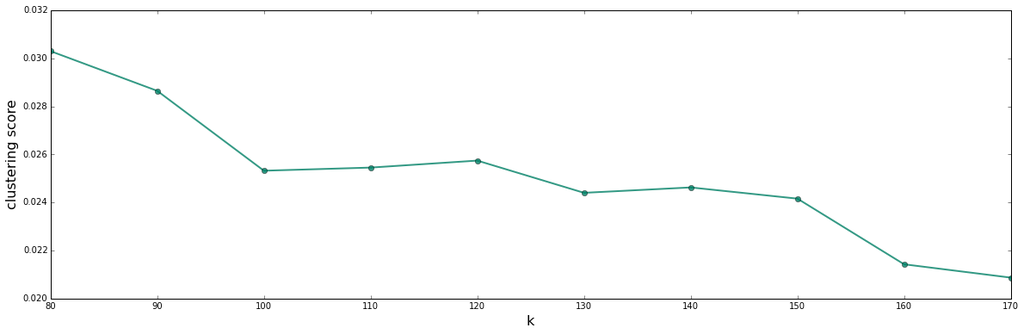

```python
k_range = np.arange(80,180,10).tolist()
scores = [(k,clusteringScoreEntropy(normalizedLabelAndDataHotEn , k,'random',maxIterations=70,kruns=5)) for k in k_range]
dfScore = pd.DataFrame(scores,columns =['k','SSE'])
DrawFindingKResult(dfScore)
```

The last experiment we use whole data set with both numberical and categorical. Because of long running time, we won't try with larger numbers of re-run k-mean. In this case, we will choose the best k is around 100~110 because entropy decrease slowly from 100 to 150 and greatly at the point 160. But it takes a long step to reduce more so we should stop at the point 100~110. As can be seen, the result is close to the one we obtained from WSSSE (k=110). From the result of 3 experiments of testing k, WSSSE is not really bad metrices but it cannot use to compared 2 models which have different dimensions. So we think it is better to use entropy in this problem.

## SILHOUETTE MEASUREMENT

The silhouette plot displays a measure of how close each point in one cluster is to points in the neighboring clusters and thus provides a way to assess parameters like number of clusters visually. This measure has a range of [-1, 1].  
Silhouette coefficients (as these values are referred to as) near +1 indicate that the sample is far away from the neighboring clusters. A value of 0 indicates that the sample is on or very close to the decision boundary between two neighboring clusters and negative values indicate that those samples might have been assigned to the wrong cluster.  
The official silhouette is quite expensive, we need to compute distance from one point to other clusters by averaging distances to all of the point in those clusters. After that, we find closest ones. In this case, our computation go up to $5e+6*5e+6 = 2.5e+13$ operations. The running time is quite expensive for just the test. In our version, we just compute average to others cluster by using distance to its centers. Even it somehows is not really correct but we just use it for visualization and examining the result.

```python
def get_silhouette_RDD(partition,centroids,clusters):
    re = []
    for point in partition:
        # get first 2 lowest centroid
        distanceToClosest = [(ind,euclidean_distance(point,centroid)) for ind,centroid in enumerate(centroids)]
        distanceToClosest = sorted(distanceToClosest,key=lambda x:x[1])

        # return sihouette value
        re.append((distanceToClosest[0][0],clusters.predict(point)))
    return iter(re)

a = data.mapPartitions(lambda x : get_silhouette_RDD(x,bCentroids.value,bClusters.value)).cache()
```

```python
import pyspark.sql.functions as func
import operator as op
def euclidean_distance(a, b):
    c = a - b
    return np.sqrt(c.T.dot(c))

def get_silhouette(a,b): return (b-a)/np.max([a,b])

def get_silhouette_RDD(partition,clusters):
    re = []
    for point in partition:
        # get first 2 lowest centroid
        distanceToClosest = [(ind,euclidean_distance(point,centroid)) for ind,centroid in enumerate(clusters)]
        distanceToClosest = sorted(distanceToClosest,key=lambda x:x[1])

        # return sihouette value
        re.append((distanceToClosest[0][0],get_silhouette(distanceToClosest[0][1],distanceToClosest[1][1])))
    return iter(re)
```

```python
def MeasureSilhouette(data, clusters):
    bCentroids = sc.broadcast(clusters.centers)
    global bCentroids

    silhouetteScore = data.mapPartitions(lambda x : get_silhouette_RDD(x,bCentroids.value)).cache()

    avg_silhoulletScore = silhouetteScore.map(lambda x: x[1]).reduce(add)/silhouetteScore.count()
    return [silhouetteScore,avg_silhoulletScore]
```

```python
def silhouettePlot(silhouetteScore,silhoueteAvg,nCluster,size):
    # sort silhouette
    silhouetteScore = silhouetteScore.sortBy(lambda a: -a[1]).cache()
    points = silhouetteScore.collect()

    # get cluster id
    clusterID = np.arange(nCluster)
    sample_silhouette_values = pd.DataFrame(points,columns=['label','value']).sort(columns=['value'],ascending=[0])

    # Create a subplot with 1 row and 2 columns
    fig, ax1 = plt.subplots(1, 1)
    fig.set_size_inches(size[0], size[1])

    ax1.set_xlim([-0.1, 1])
    ax1.set_ylim([0, len(sample_silhouette_values) + (nCluster + 1) * 10000])

    y_lower = 10
    for i in range(nCluster):

        # Aggregate the silhouette scores for samples belonging to
        # cluster i, and sort them
        ith_cluster_silhouette_values = \
            sample_silhouette_values[sample_silhouette_values.label == clusterID[i]].value

        ith_cluster_silhouette_values = np.sort(ith_cluster_silhouette_values)

        size_cluster_i = ith_cluster_silhouette_values.shape[0]
        y_upper = y_lower + size_cluster_i

        color = cm.spectral(float(i) / nCluster)
        ax1.fill_betweenx(np.arange(y_lower, y_upper),
                          0, ith_cluster_silhouette_values,
                          facecolor=color, edgecolor=color, alpha=0.7)

        # Label the silhouette plots with their cluster numbers at the middle
        ax1.text(-0.05, y_lower + 0.5 * size_cluster_i, str(i))

        # Compute the new y_lower for next plot
        y_lower = y_upper + 10000  # 10 for the 0 samples

        ax1.set_title("The silhouette plot for the various clusters.")
        ax1.set_xlabel("The silhouette coefficient values")
        ax1.set_ylabel("Cluster label")

    # The vertical line for average silhouette score of all the values
    ax1.axvline(x=silhoueteAvg, color="red", linestyle="--")

    ax1.set_yticks([])  # Clear the yaxis labels / ticks
    ax1.set_xticks([-0.1, 0, 0.2, 0.4, 0.6, 0.8, 1,1.1])

    plt.title(("Silhouette analysis for KMeans clustering on sample data "
                  "with n_clusters = %d" % nCluster),
                 fontsize=14, fontweight='bold')

    plt.show()
```

```python
clustersUnNorm = clusteringTraining(data, 60,initializationMode='random',epsilon=1e-6,maxInt=70,kruns=5)
```

```
----------------------------------------------------------------------------------------------------
Mode:  random , maxIteration:  70 , runs:  5
k= 60 RUNNING =====	 Best WSSSE = 6.38304e+17 --- 341.92666387557983 seconds ---
```

```python
start = time.time()
[silhouetteScore,silhoueteAvg] = MeasureSilhouette(data,clustersUnNorm)
print('Silhouette average value = %f --- %f second'%(silhoueteAvg,time.time()-start))
```

```
Silhouette average value = 0.636653 --- 81.605461 second
```

This experiement just want to show the running time of our implementation. At the beginning, I predicted the label of each point and find distance to predicted label. Afterthat, we find distance to other clusters and collect the smallest one. It takes more than 140s. Then I noticed that, the silhouette value is never less than 0 because k-means label the point based on the smallest distance. At the end, I only need to find distance to all centroids and take 2 smallest one (first one is our labeled centroid and second one is closest neighbor centroid) and it only takes around 80s to run the test.

### *Numberical data with normalization and best k=110*

```python
clustersNorm = clusteringTraining(normalizedData, 110,initializationMode='random',epsilon=1e-6,maxInt=70,kruns=5)
start = time.time()
[silhouetteScore,silhoueteAvg] = MeasureSilhouette(normalizedData,clustersNorm)
print('Silhouette average value = %f --- %f second'%(silhoueteAvg,time.time()-start))
```

```
----------------------------------------------------------------------------------------------------
Mode:  random , maxIteration:  70 , runs:  5
k= 110 RUNNING =====	 Best WSSSE = 4.70809e+07 --- 419.21403789520264 seconds ---
Silhouette average value = 0.754051 --- 148.286444 second
```

We just show you again that normalization data perform better than without normalization. The silhoueete value close to 1 show that our data point is closer to predicted cluster than neighbor cluster. In this case, we obtain value as 0.75 shows that our clustering is quite good.

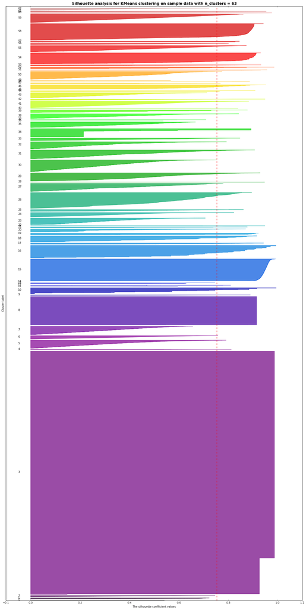

```python
silhouettePlot(silhouetteScore,silhoueteAvg,clustersNorm.k,[20,40])
```

From the graph, you can see there are some "big" clusters (cluster has enormous data points) which has high silhoutte value. That means those clusters is really good, for example cluster 3,8,15,54,58. That makes our average silhoutte so high. In addition, cluster 3 also shows you there are lots of identical points which give you same silhouette value that's why the shape is the rectangle like the figure.

### *Numberical and categorical data with normalization and best k=110*

```python
clustersNorm = clusteringTraining(normalizedDataHotEn, 110,initializationMode='random',epsilon=1e-6,maxInt=70,kruns=5)
start = time.time()
[silhouetteScore,silhoueteAvg] = MeasureSilhouette(normalizedDataHotEn,clustersNorm)
print('Silhouette average value = %f --- %f second'%(silhoueteAvg,time.time()-start))
```

```
----------------------------------------------------------------------------------------------------
Mode:  random , maxIteration:  70 , runs:  5
k= 110 RUNNING =====	 Best WSSSE = 3.01302e+08 --- 586.9529168605804 seconds ---
Silhouette average value = 0.831583 --- 161.721605 second
```

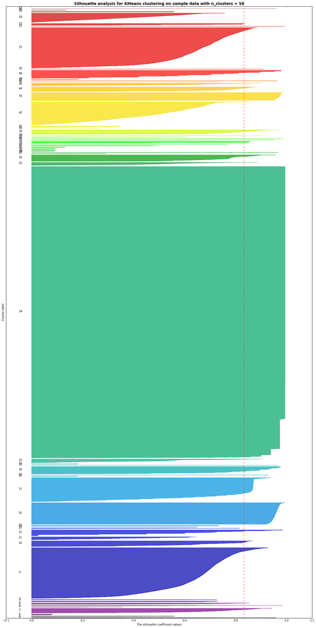

```python
silhouettePlot(silhouetteScore,silhoueteAvg,clustersNorm.k,[20,40])
```

[figure not shown]

More specifically, when using a k-means clustering approach towards anomaly detection, the outlier score is calculated in one of two ways. The simplest is the point's distance from its closest centroid. However, this approach is not as useful when there are clusters of differing densities. To tackle that problem, the point's relative distance to it's closest centroid is used, where relative distance is defined as the ratio of the point's distance from the centroid to the median distance of all points in the cluster from the centroid. This approach to anomaly detection is sensitive to the value of k. Also, if the data is highly noisy, then that will throw off the accuracy of the initial clusters, which will decrease the accuracy of this type of anomaly detection. The time complexity of this approach is obviously dependent on the choice of clustering algorithm, but since most clustering algorithms have linear or close to linear time and space complexity, this type of anomaly detection can be highly efficient.

#### Question 14

Implement K-means on Spark so that It can work with large datasets in parallel. Test your algorithm with our dataset in this notebook. Compare our algorithm with the algorithm from MLLIB.

Let's clarify the meaning of this question: what we want is for students to design the K-means algorithm for the parallel programming model exposed by Spark. You are strongly invited to use the Python API (pyspark). So, at the end of the day, you will operate on RDDs, and implement a `map/reduce` algorithm that performs the two phases of the standard K-means algorithm, i.e. the assignment step and the update step.

The idea of implimentation parallel K-means is in each iteration, to create an accumulator for each updated centroid to store sum of all vectors in clusters and number of elements and broadcast the current centroids. Using mapParition(), we run jobs parallelly at the level of parition to find closest centroid for each data point and add into accumulator. After walking through all points, we check conditions and update the centroids if possible.  
Why do we use mapPartition? First, we don't need a reduce job so we should use map job only to avoid shuffling. Second, mapPartitions() have better performance than map(). mapPartitions() is called once for each Partition unlike map() which is called for each element in the RDD. For example, if we have 100K elements in a particular RDD partition then we will fire off the function 100K times when we use map(). Conversely, if we use mapPartitions() then we will only call the particular function one time for that RDD partition.

```python
from pyspark import AccumulatorParam
class VectorAccumulatorParam(AccumulatorParam):
    def zero(self, value):
        # [k-value,vector dim]
        sums = np.zeros(np.shape(value[0]))
        counts = np.zeros(len(value[1]))
        return [sums, counts]

    def addInPlace(self, v1, v2):
        v1[0] += v2[0]
        v1[1] += v2[1]
        return v1
```

```python
def euclidean_distance_square(a, b):
    c = a - b
    return c.T.dot(c)

def euclidean_distance(a, b):
    c = a - b
    return np.sqrt(c.T.dot(c))

def getPartitionDistance(iterator,centroids):
    total = 0
    for point in iterator:
        i = find_closest_centroid(point, centroids)
        total += euclidean_distance_square(centroids[i], point)
    return iter(np.array([total]))

# Calculate the mean of the distance of each point to its closest centroid
def getError(data):
    errors_vect = data.mapPartitions(lambda x: getPartitionDistance(x,bCentroids.value))
    error = errors_vect.reduce(add)
    return error
```

We implement improved version for calculating euclidean distance using matrix form instead of sum of all elements from difference of 2 vectors. It will be slow.

```python
def randomize_centroids_parallel(data,rate, k):
    centroids = data.takeSample(False, rate).take(k)
    return centroids

def find_closest_centroid(datapoint, centroids):
    # find the index of the closest centroid of the given data point.
    distToCentroids = min(enumerate(centroids), key=lambda x: euclidean_distance_square(datapoint, x[1]))[0]
    return distToCentroids

def findNewCentroid(iterator, centers,param):
    sums = np.zeros(param)
    counts = np.zeros(param[0])
    for point in iterator:
        i = find_closest_centroid(point, centers)
        sums[i] += point
        counts[i] += 1
    accum.add([sums, counts])
    yield

def kmeans_parallel(data, k=2, runs=1, maxIterations=10,epsilon=1e-5):
    # print config
    print(''.join(['-']*100))
    print("MaxIteration: ", maxIterations, ", runs: ", runs)
    print("k=",k,"RUNNING ",end="")

    # vector dim
    ndim = len(data.take(1)[0])
    bParam = sc.broadcast([k,ndim])
    sums = np.zeros([k,ndim])
    counts = np.zeros(k)
    OptimalSSE = np.inf
    OptimalCentroid = []
    start_time = time.time()
    for i in range(runs):
        print("=",end="")

        # randomize the centroids
        centroids = randomize_centroids_parallel(data,1e-5,k)
        bCentroids = sc.broadcast(centroids)
        global bCentroids

        for iteration in range(maxIterations):
            print("-",end="")
            # init empty clusters
            accum = sc.accumulator([sums, counts], VectorAccumulatorParam())
            global accum

            data.mapPartitions(lambda x: findNewCentroid(x, bCentroids.value,bParam.value)).collect()

            # keep the current position of centroids before changing them
            old_centroids = centroids

            # update centroids
            centroids = np.array([s/nElements for s, nElements in zip(accum.value[0], accum.value[1])])
            bCentroids = sc.broadcast(centroids)

            # if the stop criteria are met, stop the algorithm
            if check_converge(centroids, old_centroids, iteration, epsilon):
                break
        # get optimal centroids
        error = getError(data)
        if error < OptimalSSE:
            OptimalSSE = error
            OptimalCentroid = centroids

    run_time = time.time() - start_time
    print("\t Best WSSSE = %.5e --- %s seconds ---" % (OptimalSSE,run_time))
    return run_time
```

In this experiment, we want to observe how good our implementation through its performance. Testing on different k in set [2,20,100] to observe the running time of Kmeans in MLLIB and our version

## Experiment on different K

#### *Implementation Version*

```python
k_range = [2,20,100]
for k in k_range:
    kmeans_parallel(data, k=k,epsilon=1e-4,maxIterations=3,runs=1)
```

```
----------------------------------------------------------------------------------------------------
MaxIteration:  3 , runs:  1
k= 2 RUNNING =---	 Best WSSSE = 6.37926e+18 --- 21.54325795173645 seconds ---
----------------------------------------------------------------------------------------------------
MaxIteration:  3 , runs:  1
k= 20 RUNNING =---	 Best WSSSE = 6.37811e+18 --- 98.5375120639801 seconds ---
----------------------------------------------------------------------------------------------------
MaxIteration:  3 , runs:  1
k= 100 RUNNING =---	 Best WSSSE = 6.36679e+18 --- 356.66175508499146 seconds ---
```

#### *Library Version*

```python
for k in k_range:
    clusteringScoreWithParam(data,k, initializationMode='random',epsilon=1e-4,maxInt=3,kruns=1)
```

```
----------------------------------------------------------------------------------------------------
Mode:  random , maxIteration:  3 , runs:  1
k= 2 RUNNING =	 Best WSSSE = 6.37937e+18 --- 6.757186651229858 seconds ---
----------------------------------------------------------------------------------------------------
Mode:  random , maxIteration:  3 , runs:  1
k= 20 RUNNING =	 Best WSSSE = 6.29597e+18 --- 7.549329519271851 seconds ---
----------------------------------------------------------------------------------------------------
Mode:  random , maxIteration:  3 , runs:  1
k= 100 RUNNING =	 Best WSSSE = 6.21788e+18 --- 7.989511489868164 seconds ---
```

Increase number of clusters, we increase number of computations in **find_closest_centroid**, which compute distance from one point to all clusters. However, we increase k 10 times but running time is only nearly 5 times. In addition, it seems the implementation kmeans converge slower than library.

## Experiment on different iterations

#### *Library Version*

```python
iteration_range = range(3,15,3)
for i in iteration_range:
    clusteringScoreWithParam(data,2,initializationMode='random',epsilon=1e-4,maxInt=i,kruns=1)
```

```
----------------------------------------------------------------------------------------------------
Mode:  random , maxIteration:  3 , runs:  1
k= 2 RUNNING =	 Best WSSSE = 6.37937e+18 --- 6.621830463409424 seconds ---
----------------------------------------------------------------------------------------------------
Mode:  random , maxIteration:  6 , runs:  1
k= 2 RUNNING =	 Best WSSSE = 6.37939e+18 --- 6.060937881469727 seconds ---
----------------------------------------------------------------------------------------------------
Mode:  random , maxIteration:  9 , runs:  1
k= 2 RUNNING =	 Best WSSSE = 3.05255e+18 --- 8.829440593719482 seconds ---
----------------------------------------------------------------------------------------------------
Mode:  random , maxIteration:  12 , runs:  1
k= 2 RUNNING =	 Best WSSSE = 6.37939e+18 --- 6.249691009521484 seconds ---
```

#### *Implementation version*

```python
for i in iteration_range:
    kmeans_parallel(data, k=2,epsilon=1e-4,maxIterations=i,runs=1)
```

```
----------------------------------------------------------------------------------------------------
MaxIteration:  3 , runs:  1
k= 2 RUNNING =---	 Best WSSSE = 6.37676e+18 --- 20.889164924621582 seconds ---
----------------------------------------------------------------------------------------------------
MaxIteration:  6 , runs:  1
k= 2 RUNNING =------	 Best WSSSE = 6.37713e+18 --- 37.33038830757141 seconds ---
----------------------------------------------------------------------------------------------------
MaxIteration:  9 , runs:  1
k= 2 RUNNING =---------	 Best WSSSE = 6.37939e+18 --- 53.220006227493286 seconds ---
----------------------------------------------------------------------------------------------------
MaxIteration:  12 , runs:  1
k= 2 RUNNING =-----------	 Best WSSSE = 6.37909e+18 --- 65.11225175857544 seconds ---
```

Increase number of iterations, we increase number of loops in updating the clusters. However, if you see the last experiment with iteration = 12. Our implemention converges at iteration 11th (number of '-' show number of iteration). As I give some comment above that our implemention seem converge slowler than library so it can need more iteration than library version. That is also a reason that make it run slower.

## Experiment on different re-run K-means

#### *Library Version*

```python
runs_range = np.arange(1,5)
for t in runs_range:
    clusteringScoreWithParam(data,2, initializationMode='random',epsilon=1e-4,maxInt=6,kruns=t)
```

```
----------------------------------------------------------------------------------------------------
Mode:  random , maxIteration:  6 , runs:  1
k= 2 RUNNING =	 Best WSSSE = 6.37937e+18 --- 7.642729997634888 seconds ---
----------------------------------------------------------------------------------------------------
Mode:  random , maxIteration:  6 , runs:  2
k= 2 RUNNING ==	 Best WSSSE = 3.47336e+18 --- 15.120243072509766 seconds ---
----------------------------------------------------------------------------------------------------
Mode:  random , maxIteration:  6 , runs:  3
k= 2 RUNNING ===	 Best WSSSE = 3.08329e+18 --- 20.46511173248291 seconds ---
----------------------------------------------------------------------------------------------------
Mode:  random , maxIteration:  6 , runs:  4
k= 2 RUNNING ====	 Best WSSSE = 3.08329e+18 --- 30.450631141662598 seconds ---
```

```python
for t in runs_range:
    kmeans_parallel(data,2, epsilon=1e-4,maxIterations=6,runs=t)
```

```
----------------------------------------------------------------------------------------------------
MaxIteration:  6 , runs:  1
k= 2 RUNNING =------	 Best WSSSE = 6.37598e+18 --- 38.608826637268066 seconds ---
----------------------------------------------------------------------------------------------------
MaxIteration:  6 , runs:  2
k= 2 RUNNING =------=------	 Best WSSSE = 6.37721e+18 --- 77.30786108970642 seconds ---
----------------------------------------------------------------------------------------------------
MaxIteration:  6 , runs:  3
k= 2 RUNNING =------=------=------	 Best WSSSE = 6.37920e+18 --- 113.1062228679657 seconds ---
----------------------------------------------------------------------------------------------------
MaxIteration:  6 , runs:  4
k= 2 RUNNING =------=------=------=------	 Best WSSSE = 6.37866e+18 --- 147.2083604335785 seconds ---
```

As you remembered, we implemented K-means runs by a loop so that why the running times is approximately multiple running times of running once time. It happens the same in our implementation.

## Feature Selection in Unsupervised learning

It should be noted that a variable not containing any relevant information (say, the telephone number of each person) is worse than useless, because it will make the clustering less apparent. The occurrence of several such “trash variables” will kill the whole clustering because they yield a lot of random terms in the distances, thereby hiding the useful information provided by the other variables. Therefore, such noninformative variables must be given a zero weight in the analysis. However, it is risky to remove some dimensions without understanding the data and the clustering problem. I create an example with illustration to give you an example:

[figure not shown]

One of the criteria we read that we choose dimension have higher variance to seperately data. As can be seen in this example, if we have 2 clusters, red circle shows you the best choice for clustering. Following the image, the vertical axis is not really helpful in clustering with k=2, we can use only distance from horizontal axis to cluster the data. Even vertical dimension have higher variance than horizontal one that the point spread out on that dimension. So removing dimension in this case is not really correct. However, if we try if k=3, you can see that vertical axis is quite helpful to seperate 3 clusters, specially between orange and blue which was in same cluster before.  
So what is our conclusion? We have to be so careful to do dimension reduction in clustering problem. If you have a good metrics to evaluate our result so it is possible to do it. In this problem, we still do not know to how evaluate the final result (anomaly points) so that we just want to present the ideas some advantages and problems inside feature selections in unsupervised learning.